# S5_Informe

### Descriptores de Posición

#### Promedio

```r
mean(DF$review_scores_checkin, na.rm=TRUE)
```

```
## [1] 4.780533
```

```r
##Hallamos mediana
median(DF$review_scores_checkin, na.rm=TRUE)
```

```
## [1] 4.92
```

```r
##Hallamos los cuantiles generales
##Elcuantial 0% pertenece al minimo valor y cuantil del 100% pertenece al maximo valor
quantile(DF$review_scores_checkin,type=2, na.rm = TRUE)
```

```
##   0%  25%  50%  75% 100%
## 1.00 4.77 4.92 5.00 5.00
```

El 25% de review_scores_checkin es menor-igual de 4.77, el 50% menor-igual de 4.92, el 75% menor-igual de 5 y el 100% de 5.

#### Moda

```r
##Hallamos la moda,es decir, el valor que se repite mas veces
table(DF$review_scores_checkin)[table(DF$review_scores_checkin)==max(table(DF$review_scores_checkin))]
```

```
##  5
## 56
```

La única moda es 5. ### Descriptores de dispersión

#### Rango

```r
##Descriptores de dispersion, para review_scores_checkin.
#Hallamos el rango
rango<-max(DF$review_scores_checkin, na.rm=TRUE)-min(DF$review_scores_checkin,na.rm=TRUE)#Rango
rango
```

```
## [1] 4
```

```r
#Nos da el valor minimo y maximo
range(DF$review_scores_checkin, na.rm=TRUE)#min valor y max valor
```

```
## [1] 1 5
```

```r
#Rango intercuartil
IQR(DF$review_scores_checkin, na.rm=T)
```

```
## [1] 0.2275
```

#### Varianza

```r
##Hallamos varianza
var(DF$review_scores_checkin, na.rm=T)
```

```
## [1] 0.1932292
```

Los datos no varían mucho respecto a la media. #### Desviació estandar

```r
##Hallamos desviacion estandar
sd(DF$review_scores_checkin, na.rm=T)
```

```
## [1] 0.4395785
```

La distribución entre los datos es pequeña. #### Coeficiente de Variación

```r
##Hallamos el coeficiente de variacion, para ello se crea la funcion dada.
cv<-function(x){
  return(sd(x,na.rm=TRUE)/mean(x,na.rm=T))}
cv(DF$review_scores_checkin)
```

```
## [1] 0.09195177
```

El grado de variabilidad es baja. ### Gráficos

#### Boxplot

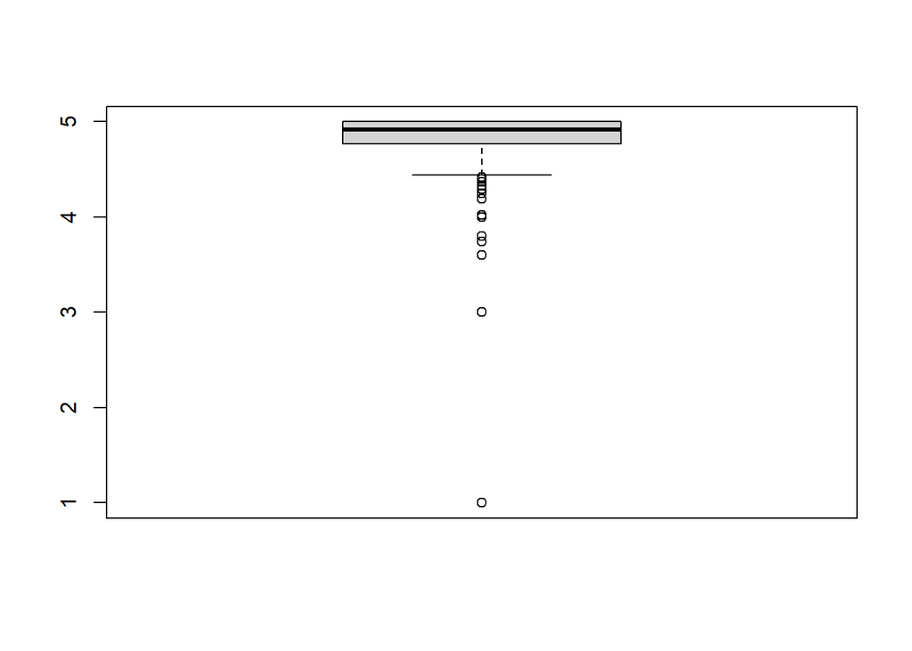

```r
#Grafica de bigotes, para identificar los datos atipicos
boxplot(DF$review_scores_checkin)
```

-El 50% de los datos se encuentran entre 4.7 y 5. -Se observa más de 6 datos atipicos por debajo de la caja.

#### De puntos

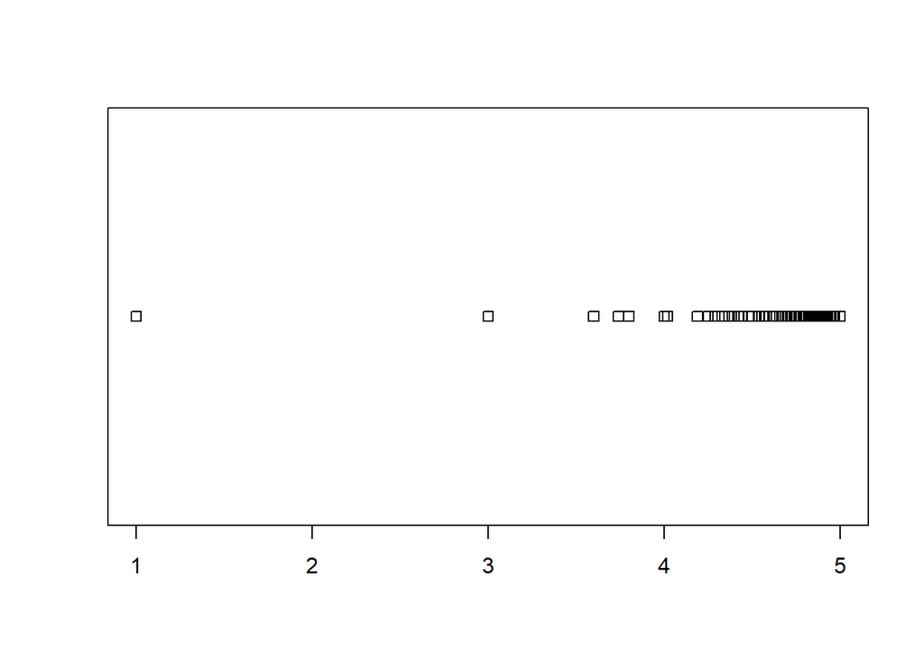

```r
#Grafica de puntos en linea recta, se usa para identficar  datos atipicos
stripchart(DF$review_scores_checkin)
```

Se confirma que los datos se concentran bastante entre 4.7 aprox. y 5.

#### Histograma

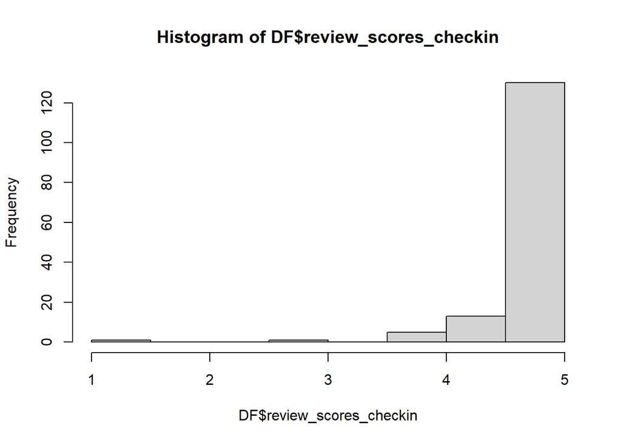

```r
#Histograma
hist(DF$review_scores_checkin)
```

La mayoría de review_scores_checkin se encuentran entre 4.5 aprox. y 5. ## review_scores_communication

### Descriptores de posición

#### Media

```r
#Descriptores de Ubicacion
##Hallamos el promedio
mean(DF$review_scores_communication, na.rm=TRUE)
```

```
## [1] 4.745867
```

```r
##Hallamos mediana
median(DF$review_scores_communication, na.rm=TRUE)
```

```
## [1] 4.905
```

La media y mediana varian poco. #### Cuantiles

```r
##Hallamos los cuantiles generales
##Elcuantial 0% pertenece al minimo valor y cuantil del 100% pertenece al maximo valor
quantile(DF$review_scores_communication,type=2,na.rm=T)
```

```
##    0%   25%   50%   75%  100%
## 1.000 4.710 4.905 5.000 5.000
```

El 25% de review_scores_communication es menor-igual de 4.710, el 50% menor-igual de 4.905, el 75% menor-igual de 5, el 100% menor-igual de 5. #### Moda

```r
##Hallamos la moda,es decir, el valor que se repite mas veces
table(DF$review_scores_communication)[table(DF$review_scores_communication)==max(table(DF$review_scores_communication))]
```

```
##  5
## 55
```

La única moda es 5. ### Descriptores de dispersión

#### Rango

```r
##Descriptores de dispersion, para review_scores_checkin.
#Hallamos el rango
rango<-max(DF$review_scores_communication, na.rm=TRUE)-min(DF$review_scores_communication,na.rm=TRUE)#Rango
rango
```

```
## [1] 4
```

```r
#Nos da el valor minimo y maximo
range(DF$review_scores_communication, na.rm=TRUE)#min valor y max valor
```

```
## [1] 1 5
```

```r
#Rango intercuartil
IQR(DF$review_scores_communication, na.rm=T)
```

```
## [1] 0.2875
```

#### Varianza

```r
##Hallamos varianza
var(DF$review_scores_communication, na.rm=T)
```

```
## [1] 0.2236217
```

Los datos varían poco respecto a la media. #### Desviación estandar

```r
##Hallamos desviacion estandar
sd(DF$review_scores_communication, na.rm=T)
```

```
## [1] 0.4728866
```

La dispersión de los datos es pequeña. #### Coeficiente de variación

```r
##Hallamos el coeficiente de variacion, para ello se crea la funcion dada.
cv<-function(x){
  return(sd(x,na.rm=TRUE)/mean(x,na.rm=T))}
cv(DF$review_scores_communication)
```

```
## [1] 0.09964178
```

El grado de variabilidad es bastante pequeña. ### Gráficos

#### Boxplot

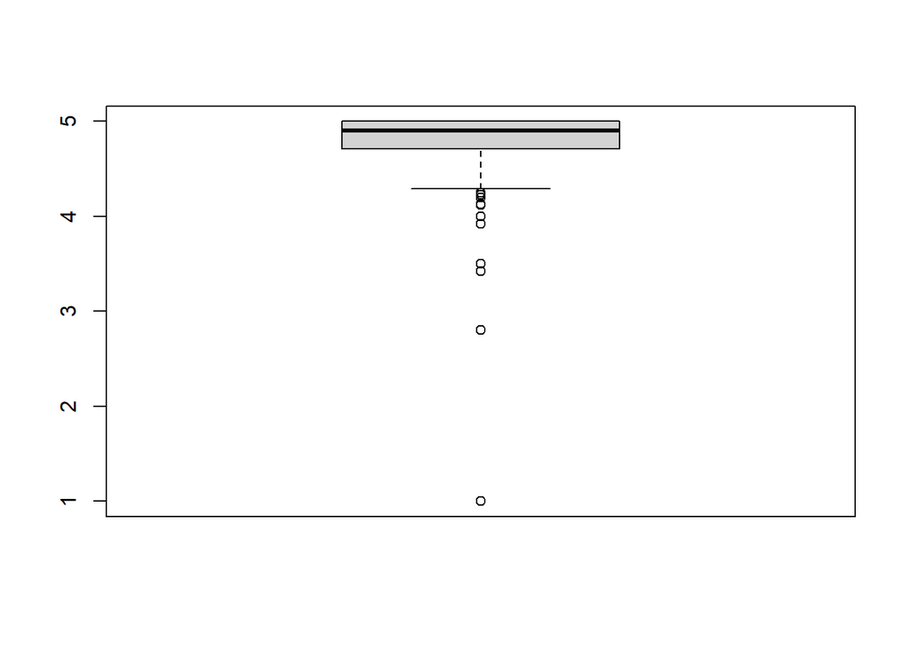

```r
#Grafica de bigotes, para identificar los datos atipicos
boxplot(DF$review_scores_communication)
```

-El 50% de los datos se encuentran entre 4.7 y 5. -Se observan mas de 8 datos atípicos por debajo de la caja.

#### De puntos

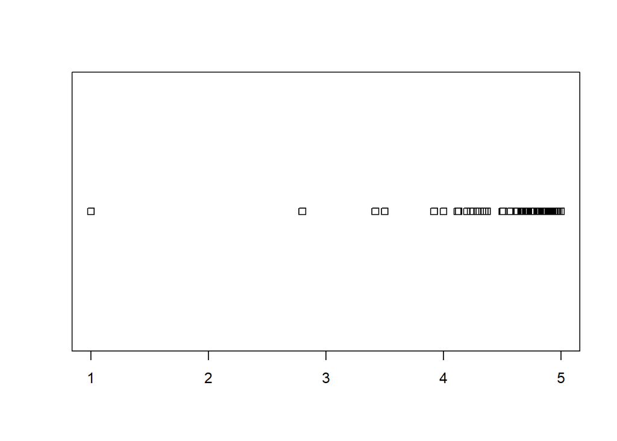

```r
#Grafica de puntos en linea recta, se usa para identficar  datos atipicos
stripchart(DF$review_scores_communication)
```

Se observa que los datos se concentran entre 4.7 aprox y 5.

#### Histograma

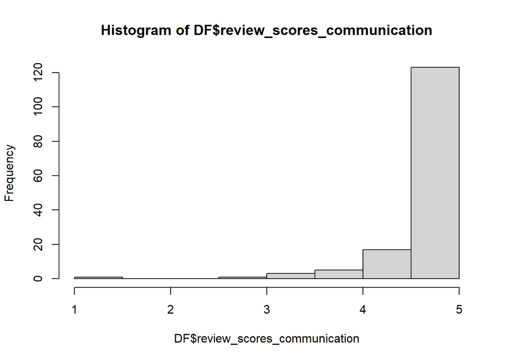

```r
#Histograma
hist(DF$review_scores_communication)
```

La mayor cantidad de review_scores_communication se encuetran entre 4.5 aprox y 5.

## review_scores_location

### Descriptores de posición

#### Media

```r
#Descriptores de Ubicacion
##Hallamos el promedio
mean(DF$review_scores_location, na.rm=TRUE)
```

```
## [1] 4.8432
```

El promedio de review_scores_location de los hospedajes es de 4.8432. #### Mediana

```r
##Hallamos mediana
median(DF$review_scores_location, na.rm=TRUE)
```

```
## [1] 4.93
```

La media y mediana, no varían mucho, eso afirma la buena distribución de los datos. #### Cuantiles

```r
##Hallamos los cuantiles generales
##Elcuantial 0% pertenece al minimo valor y cuantil del 100% pertenece al maximo valor
quantile(DF$review_scores_location,type=2,na.rm=T)
```

```
##   0%  25%  50%  75% 100%
## 4.00 4.80 4.93 5.00 5.00
```

El 25% de review_scores_location es menor-igual a 4.8, el 50% menor-igual de 4.93, el 75% es menor-igual de 5 y el 100% menor-igual de. #### Moda

```r
##Hallamos la moda,es decir, el valor que se repite mas veces
table(DF$review_scores_location)[table(DF$review_scores_location)==max(table(DF$review_scores_location))]
```

```
##  5
## 56
```

La única moda es de 5.

### Descriptores de dispersión

#### Rango

```r
##Descriptores de dispersion, para review_scores_checkin.
#Hallamos el rango
rango<-max(DF$review_scores_location, na.rm=TRUE)-min(DF$review_scores_location,na.rm=TRUE)#Rango
rango
```

```
## [1] 1
```

```r
#Nos da el valor minimo y maximo
range(DF$review_scores_location, na.rm=TRUE)#min valor y max valor
```

```
## [1] 4 5
```

```r
#Rango intercuartil
IQR(DF$review_scores_location, na.rm=T)
```

```
## [1] 0.1975
```

#### Varianza

```r
##Hallamos varianza
var(DF$review_scores_location, na.rm=T)
```

```
## [1] 0.05197224
```

Los datos no varían mucho respecto a la media. #### Desviación estandar

```r
##Hallamos desviacion estandar
sd(DF$review_scores_location, na.rm=T)
```

```
## [1] 0.2279742
```

La dispersión entre los datos es pequeña. #### Coeficiente de variación

```r
##Hallamos el coeficiente de variacion, para ello se crea la funcion dada.
cv<-function(x){
  return(sd(x,na.rm=TRUE)/mean(x,na.rm=T))}
cv(DF$review_scores_location)
```

```
## [1] 0.04707099
```

La variabilidad de los datos es bastante pequeña.

### Gráficos

#### Boxplot

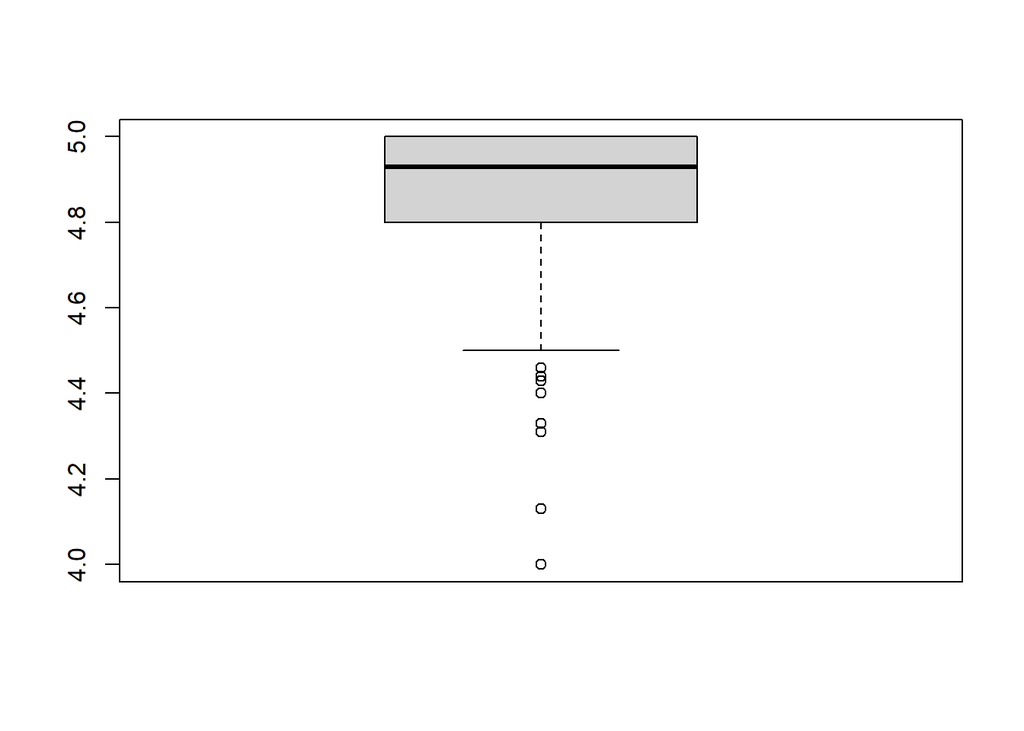

```r
#Grafica de bigotes, para identificar los datos atipicos
boxplot(DF$review_scores_location)
```

-El 50% de los datos se encuentran entre 4.8 y 5. -Observamos atípicos de 7 datos atípicos por debajo de la caja.

#### De puntos

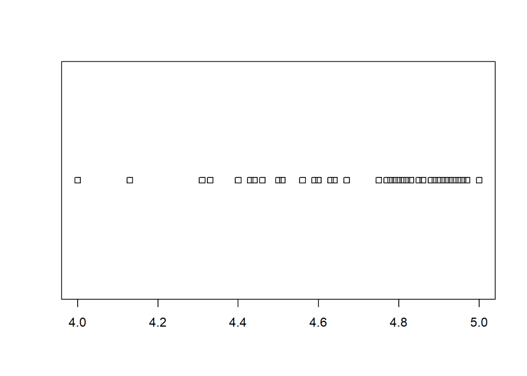

```r
#Grafica de puntos en linea recta, se usa para identficar  datos atipicos
stripchart(DF$review_scores_location)
```

Se puede observar de una mejor manera los datos atípicos. Se confirma que los datos se concentran entre 4.8 y 5.

#### Histograma

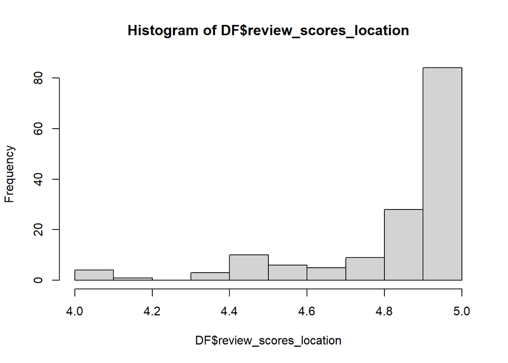

```r
#Histograma
hist(DF$review_scores_location)
```

La mayor parte de los datos se encuentran entren 4.9 aprox. y 5. ## instant_bookable

```r
DF %>% count(instant_bookable)
```

| instant_bookable | n |
| --- | --- |
| FALSE | 135 |
| TRUE | 65 |

Es categórica y tiene pocas respuestas. Se puede hallar un gráfico de barras con ella y hallar su moda.

### Gráfico

#### De barras

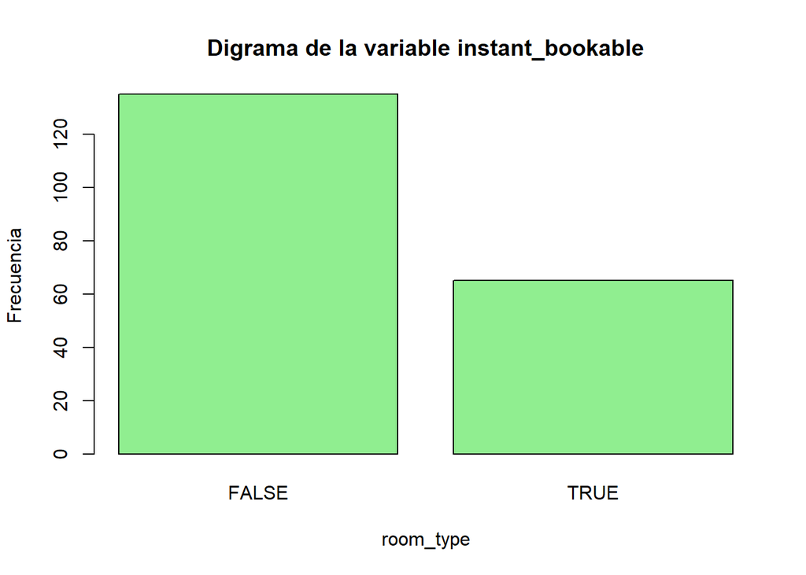

```r
x <- table(DF$instant_bookable)
barplot(x,xlab = "room_type",ylab = "Frecuencia",main = "Digrama de la variable instant_bookable",col = "light green")
```

Se observa que la mayoría de las reservas no son instantáneas. ### Moda

```r
table(DF$instant_bookable)[table(DF$instant_bookable)==max(table(DF$instant_bookable))]
```

```
## FALSE
##   135
```

La moda es False.

## reviews_per_month

### Descriptores de Posición

#### Media

```r
#Descriptores de Ubicacion
##Hallamos el promedio
mean(DF$reviews_per_month, na.rm=TRUE)
```

```
## [1] 0.9690909
```

El promedio de reviews_per_month es de 0.9690909 en los hospedajes. #### Mediana

```r
##Hallamos mediana
median(DF$reviews_per_month, na.rm=TRUE)
```

```
## [1] 0.515
```

Se observa que que la media es mayor que la mediana, por ende las distribución esta sesgada hacia la derecha. #### Cuantiles

```r
##Hallamos los cuantiles generales
##Elcuantial 0% pertenece al minimo valor y cuantil del 100% pertenece al maximo valor
quantile(DF$reviews_per_month,type=2,na.rm=T)
```

```
##    0%   25%   50%   75%  100%
## 0.010 0.160 0.515 1.290 6.770
```

```r
##Hallamos la moda,es decir, el valor que se repite mas veces
table(DF$reviews_per_month)[table(DF$reviews_per_month)==max(table(DF$reviews_per_month))]
```

```
##
## 0.02  0.1 0.14    1    2
##    4    4    4    4    4
```

#### Rango

```r
##Descriptores de dispersion, para review_scores_checkin.
#Hallamos el rango
rango<-max(DF$reviews_per_month, na.rm=TRUE)-min(DF$reviews_per_month,na.rm=TRUE)#Rango
rango
```

```
## [1] 6.76
```

```r
#Nos da el valor minimo y maximo
range(DF$reviews_per_month, na.rm=TRUE)#min valor y max valor
```

```
## [1] 0.01 6.77
```

```r
#Rango intercuartil
IQR(DF$reviews_per_month, na.rm=T)
```

```
## [1] 1.1125
```

#### Varianza

```r
##Hallamos varianza
var(DF$reviews_per_month, na.rm=T)
```

```
## [1] 1.334497
```

La dispersión de los datos respecto a la media es considerable. #### Desviación estandar

```r
##Hallamos desviacion estandar
sd(DF$reviews_per_month, na.rm=T)
```

```
## [1] 1.155204
```

La dispersión entre los datos es considerable. #### Coeficiente de variación

```r
##Hallamos el coeficiente de variacion, para ello se crea la funcion dada.
cv<-function(x){
  return(sd(x,na.rm=TRUE)/mean(x,na.rm=T))}
cv(DF$reviews_per_month)
```

```
## [1] 1.19205
```

El grado de variabilidad es alta. ### Gráficos

#### Boxplot

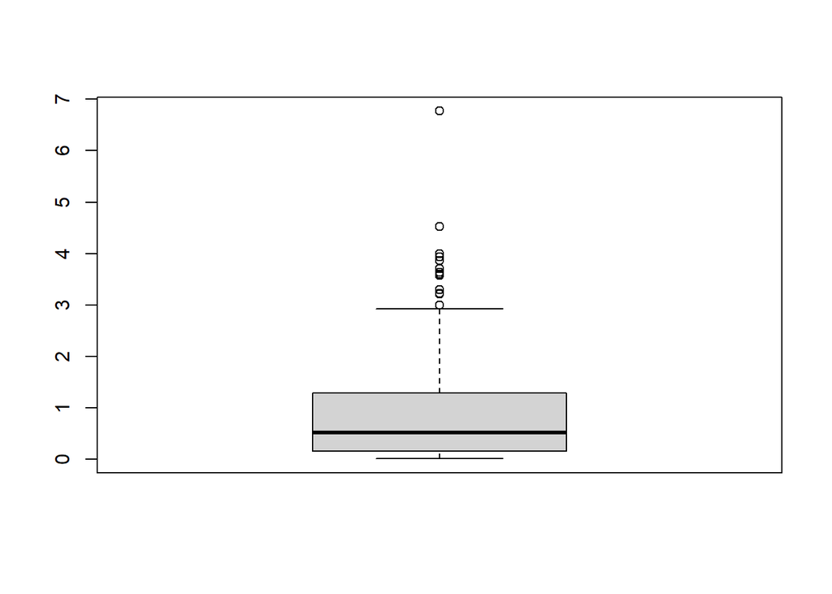

```r
#Grafica de bigotes, para identificar los datos atipicos
boxplot(DF$reviews_per_month)
```

#### De puntos

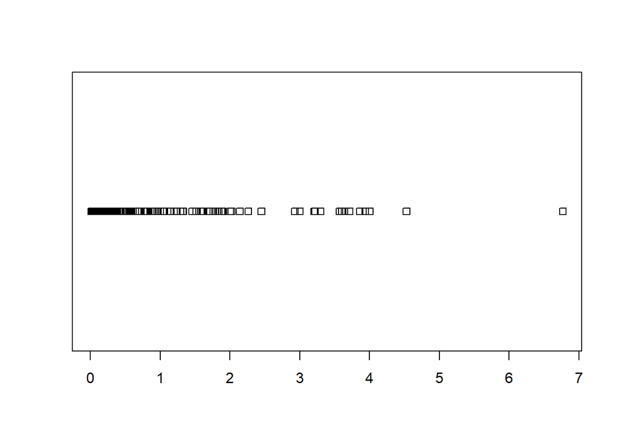

```r
#Grafica de puntos en linea recta, se usa para identficar  datos atipicos
stripchart(DF$reviews_per_month)
```

Efectivamente los datos se concentran más en entre 0 y 1.

#### Histograma

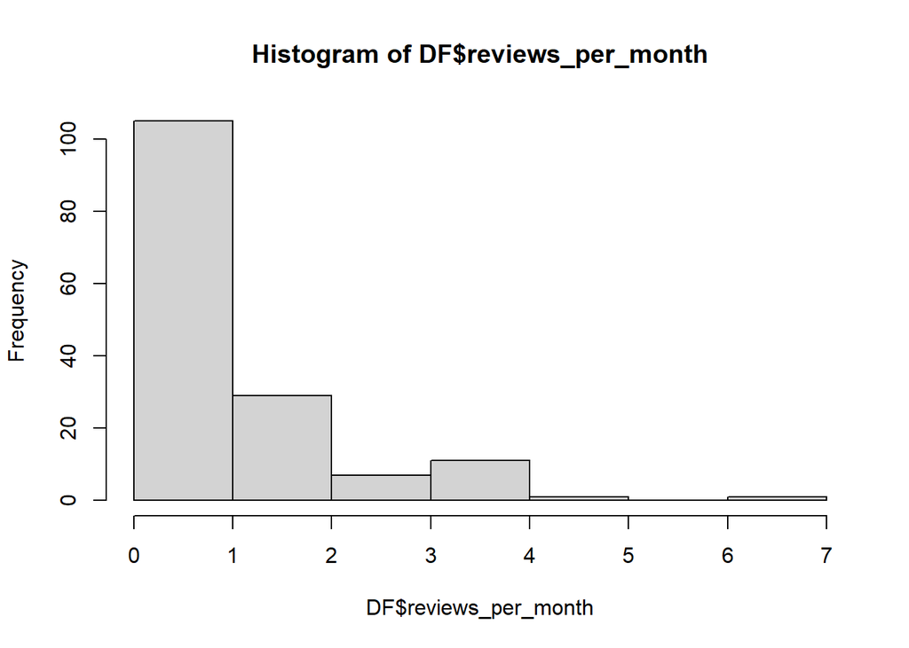

```r
#Histograma
hist(DF$reviews_per_month)
```

La mayoría de los datos se encuentran entre 0 y 1, luego entre 1 y 2.

#Analisis descriptivo de wifi

```r
class(wifi)
```

```
## [1] "character"
```

Es categórica y solo tiene 2 posibles respuestas. Se puede hallar su moda y gráfico descriptivo.

## Moda

```r
table(DF$wifi)[table(DF$wifi)==max(table(DF$wifi))]
```

```
## TRUE
##  192
```

La moda es TRUE. ## Gráficos

#### Gráfico de barras

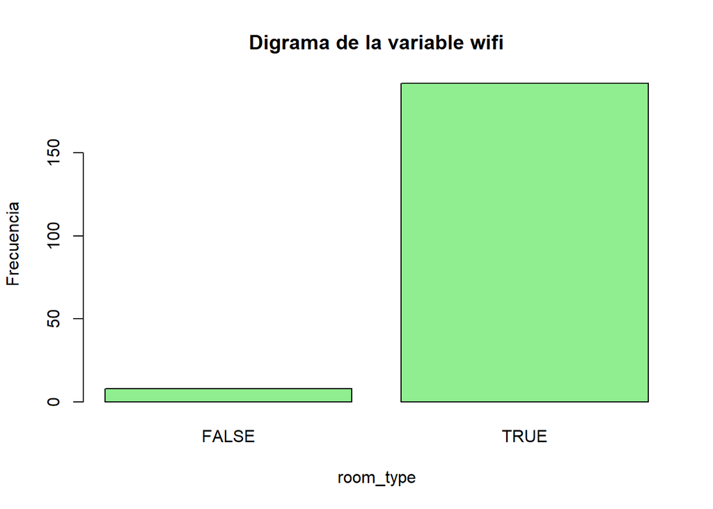

```r
x <- table(DF$wifi)
barplot(x,xlab = "room_type",ylab = "Frecuencia",main = "Digrama de la variable wifi",col = "light green")
```

Se observa que la mayoría de hospedajes tienen wifi, confirmando la moda anterior.

# Análisis de la variable hot_water

```r
class(hot_water)
```

```
## [1] "character"
```

Solo puede tener 2 valores y es categórica. Entonces, podemos hallar su moda y descriptor gráfico.

## Gráfico de barras

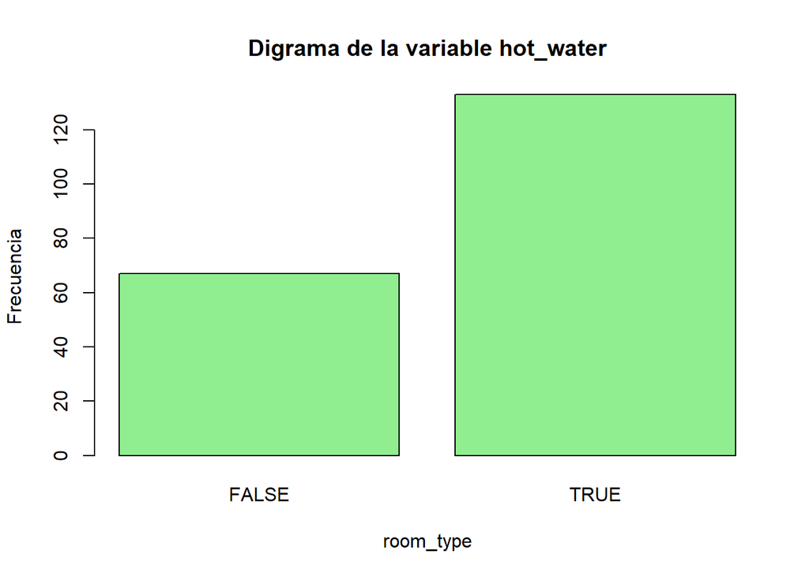

```r
x <- table(DF$hot_water)
barplot(x,xlab = "room_type",ylab = "Frecuencia",main = "Digrama de la variable hot_water",col = "light green")
```

Se observa que hay un gran porcentaje de habitaciones que poseen agua caliente. ## Moda

```r
table(DF$hot_water)[table(DF$hot_water)==max(table(DF$hot_water))]
```

```
## TRUE
##  133
```

La moda es True, quiere decir que muchas más habitaciones con agua caliente que con agua fría.

# Descriptores de 2 variables

## 1) Variables que se relacionen con review_scores_value

El propósito de este estudio es hallar las variables que tienen mayor relación al puntaje de cada hospedaje. Por lo tanto, relacionaremos todas las variables que creamos convenientes con la variable “review_scores_value”. Para todas las variables, primero hallaremos su correlación (estandarización de la covarianza) y luego su gráfica de dispersión, pues tendremos que comparar 2 variables numéricas.

## Relación entre review_scores_value y bathrooms_text

### Correlación

```r
cor(DF$review_scores_value,DF$bathrooms_text,use="complete.obs")
```

```
## [1] -0.121767
```

La relación prácticamente es nula entre estas 2 variables.

### Gráfica de dispersión

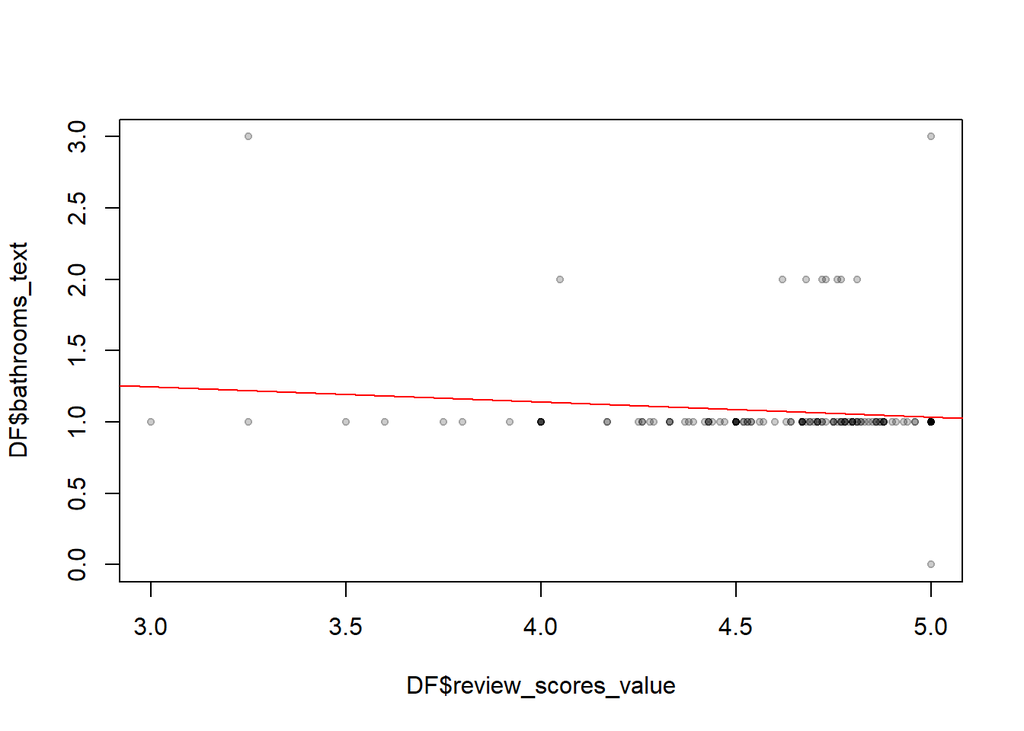

```r
plot(DF$review_scores_value,DF$bathrooms_text, pch=20, col=rgb(0,0,0,0.2)) #pch indica el icono para representar los elementos
abline(lm(DF$bathrooms_text ~ DF$review_scores_value), col = "red") #Se coloca en orden contrario al plot
```

Observamos que los datos se encuentran dispersos, correspondiendo a la correlación hallada que es casi nula. ## Relación entre review_scores_value y bedrooms

### Correlación

```r
cor(DF$review_scores_value,DF$bedrooms,use="complete.obs")
```

```
## [1] -0.02254585
```

La relación prácticamente es nula entre estas 2 variables.

### Gráfica de dispersión

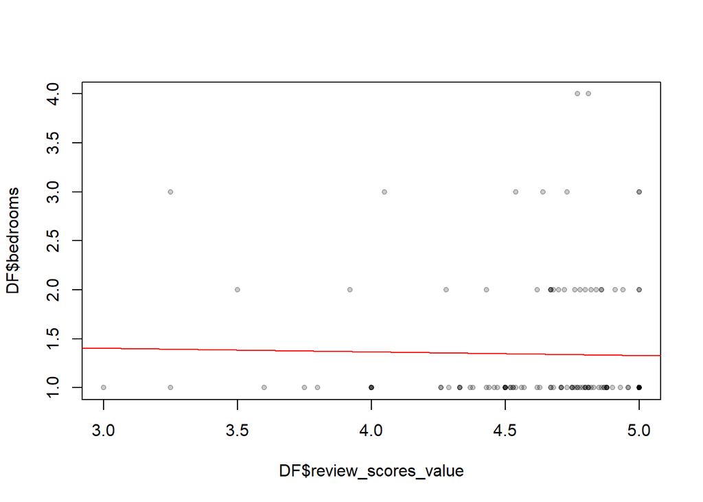

```r
plot(DF$review_scores_value,DF$bedrooms, pch=20, col=rgb(0,0,0,0.2)) #pch indica el icono para representar los elementos
abline(lm(DF$bedrooms ~ DF$review_scores_value), col = "red") #Se coloca en orden contrario al plot
```

Observamos que los datos se encuentran muy dispersos, el grado de correlación es bajísima.

## Relación entre review_scores_value y beds

### Correlación

```r
cor(DF$review_scores_value,DF$beds,use="complete.obs")
```

```
## [1] -0.1560727
```

La relación prácticamente es nula entre estas 2 variables.

### Gráfica de dispersión

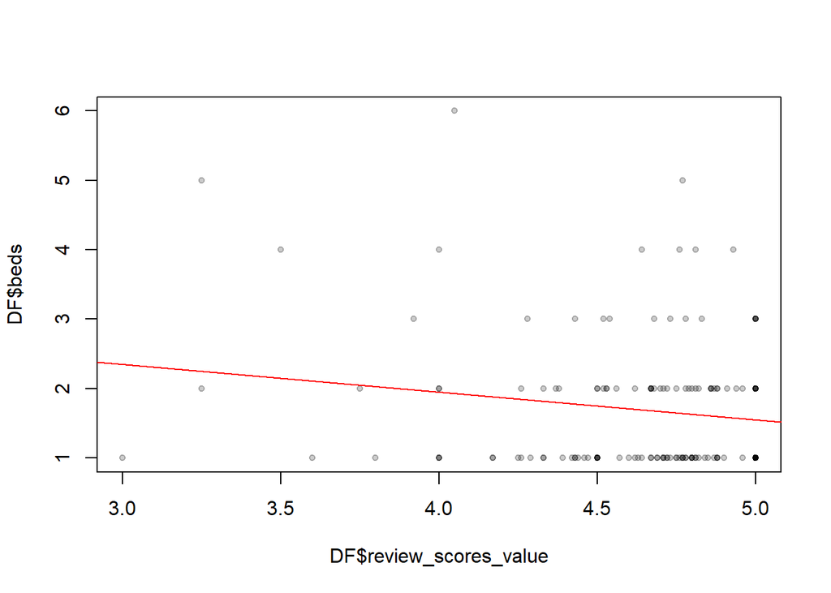

```r
plot(DF$review_scores_value,DF$beds, pch=20, col=rgb(0,0,0,0.2)) #pch indica el icono para representar los elementos
abline(lm(DF$beds ~ DF$review_scores_value), col = "red") #Se coloca en orden contrario al plot
```

Observamos que los datos se encuentran muy dispersos, por tanto la correlación es casi nula.

## Relación entre review_scores_value y price

### Correlación

```r
cor(DF$review_scores_value,DF$price,use="complete.obs")
```

```
## [1] -0.06486734
```

La relación prácticamente es nula entre estas 2 variables.

### Gráfica de dispersión

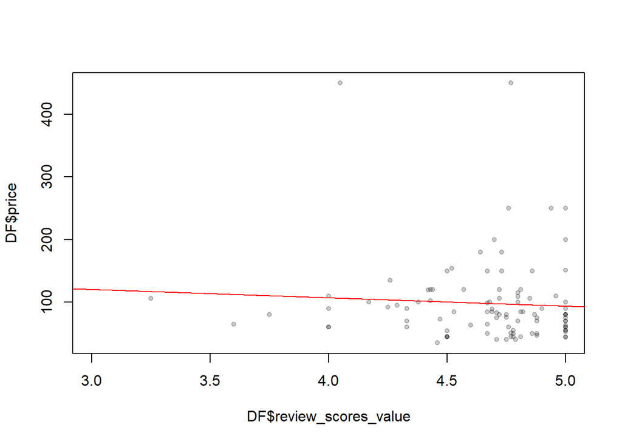

```r
plot(DF$review_scores_value,DF$price, pch=20, col=rgb(0,0,0,0.2)) #pch indica el icono para representar los elementos
abline(lm(DF$price ~ DF$review_scores_value), col = "red") #Se coloca en orden contrario al plot
```

Observamos que los datos se encuentran muy dispersos, por tanto la correlación es bastante cercana a cero.

## Relación entre review_scores_value y minimum_nights

### Correlación

```r
cor(DF$review_scores_value,DF$minimum_nights,use="complete.obs")
```

```
## [1] 0.03997592
```

La relación prácticamente es nula entre estas 2 variables.

### Gráfica de dispersión

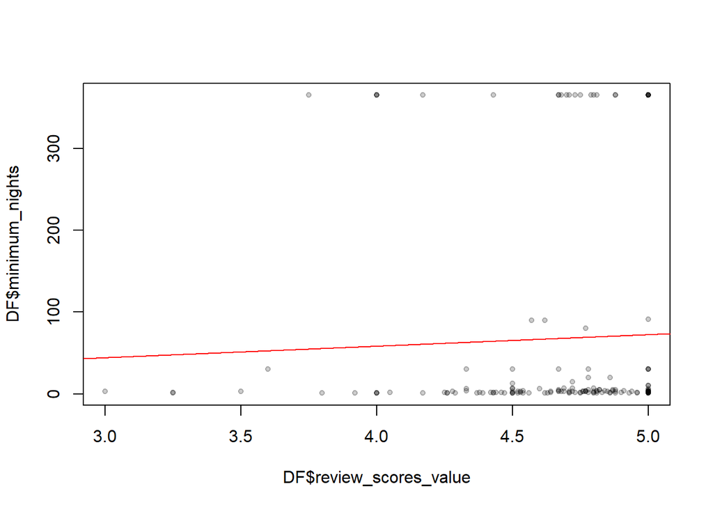

```r
plot(DF$review_scores_value,DF$minimum_nights, pch=20, col=rgb(0,0,0,0.2)) #pch indica el icono para representar los elementos
abline(lm(DF$minimum_nights ~ DF$review_scores_value), col = "red") #Se coloca en orden contrario al plot
```

Observamos que los datos están bastante dispersos, por eso el grado de correlación entre estas dos variables es cercana a cero.

## Relación entre review_scores_value y maximum_nights

### Correlación

```r
cor(DF$review_scores_value,DF$maximum_nights,use="complete.obs")
```

```
## [1] -0.0957559
```

La relación prácticamente es nula entre estas 2 variables.

### Gráfica de dispersión

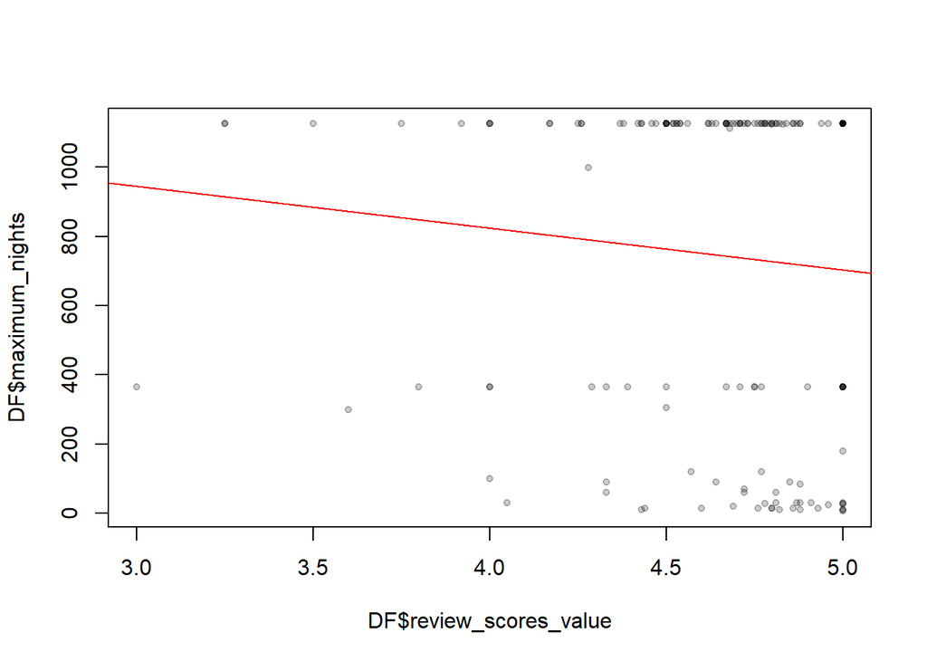

```r
plot(DF$review_scores_value,DF$maximum_nights, pch=20, col=rgb(0,0,0,0.2)) #pch indica el icono para representar los elementos
abline(lm(DF$maximum_nights ~ DF$review_scores_value), col = "red") #Se coloca en orden contrario al plot
```

Observamos que los datos estas muy dispersos, por tanto la correlación es muy cerca o casi cero.

## Relación entre review_scores_value y number_of_reviews

### Correlación

```r
cor(DF$review_scores_value,DF$number_of_reviews,use="complete.obs")
```

```
## [1] -0.05556827
```

La relación prácticamente es nula entre estas 2 variables.

### Gráfica de dispersión

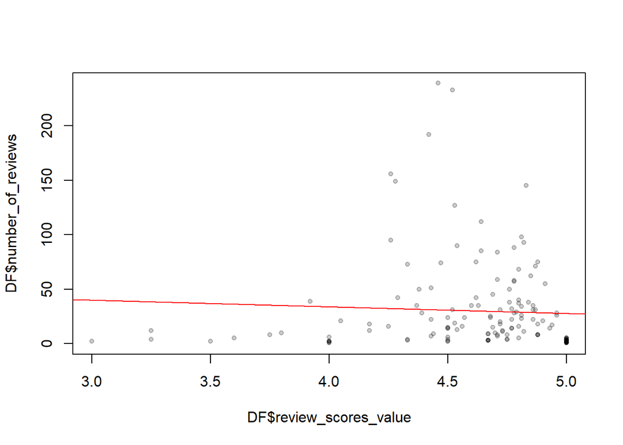

```r
plot(DF$review_scores_value,DF$number_of_reviews, pch=20, col=rgb(0,0,0,0.2)) #pch indica el icono para representar los elementos
abline(lm(DF$number_of_reviews ~ DF$review_scores_value), col = "red") #Se coloca en orden contrario al plot
```

Observamos que los datos se encuentran muy dispersos, por ende la correlacion entre estas dos variables es cercena a cero. ## Relación entre review_scores_value y review_scores_cleanliness

### Correlación

```r
cor(DF$review_scores_value,DF$review_scores_cleanliness,use="complete.obs")
```

```
## [1] 0.7643347
```

Existe una relación lineal moderadamente alta entre estas 2 variables.

### Gráfica de dispersión

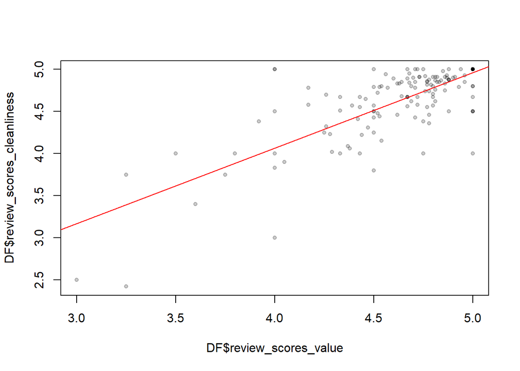

```r
plot(DF$review_scores_value,DF$review_scores_cleanliness, pch=20, col=rgb(0,0,0,0.2)) #pch indica el icono para representar los elementos
abline(lm(DF$review_scores_cleanliness ~ DF$review_scores_value), col = "red") #Se coloca en orden contrario al plot
```

Observamos que los datos tienden linealmente, es una correlación directa.

## Relación entre review_scores_value y review_scores_communication

### Correlación

```r
cor(DF$review_scores_value,DF$review_scores_communication,use="complete.obs")
```

```
## [1] 0.5716274
```

Existe una relación lineal baja, pero existente entre estas 2 variables.

### Gráfica de dispersión

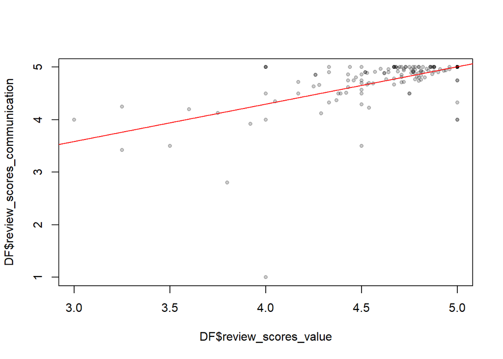

```r
plot(DF$review_scores_value,DF$review_scores_communication, pch=20, col=rgb(0,0,0,0.2)) #pch indica el icono para representar los elementos
abline(lm(DF$review_scores_communication ~ DF$review_scores_value), col = "red") #Se coloca en orden contrario al plot
```

Observamos que los datos entre estas dos variables siguen una tendencia de correlación directa.

## Relación entre review_scores_value y review_scores_location

### Correlación

```r
cor(DF$review_scores_value,DF$review_scores_location,use="complete.obs")
```

```
## [1] 0.3314568
```

Existe una relación lineal baja, pero existente entre estas 2 variables.

### Gráfica de dispersión

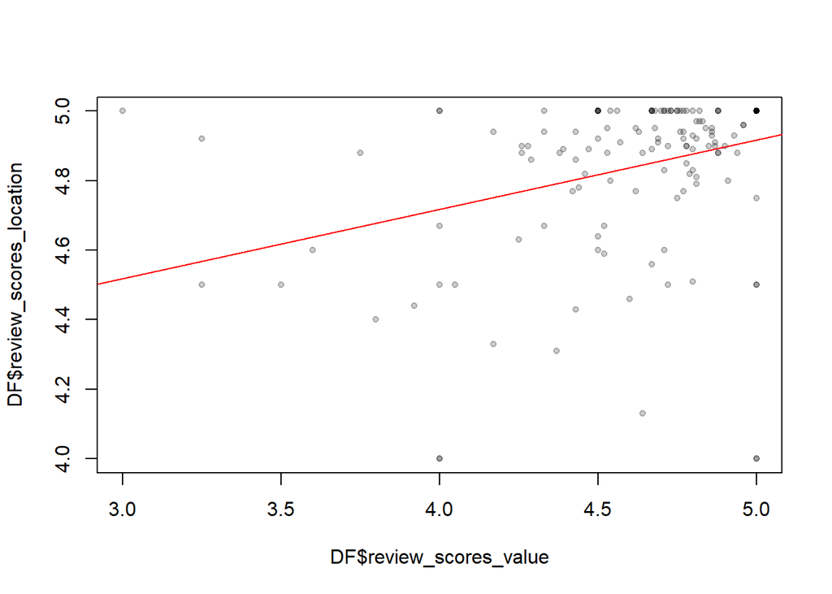

```r
plot(DF$review_scores_value,DF$review_scores_location, pch=20, col=rgb(0,0,0,0.2)) #pch indica el icono para representar los elementos
abline(lm(DF$review_scores_location ~ DF$review_scores_value), col = "red") #Se coloca en orden contrario al plot
```

Observamos que los datos siguen una pequeña tendencia lineal, por eso la correlación es baja. ## Relación entre review_scores_value y reviews_per_month

### Correlación

```r
cor(DF$review_scores_value,DF$reviews_per_month,use="complete.obs")
```

```
## [1] -0.285331
```

La relación es bastante baja entre estas 2 variables.

### Gráfica de dispersión

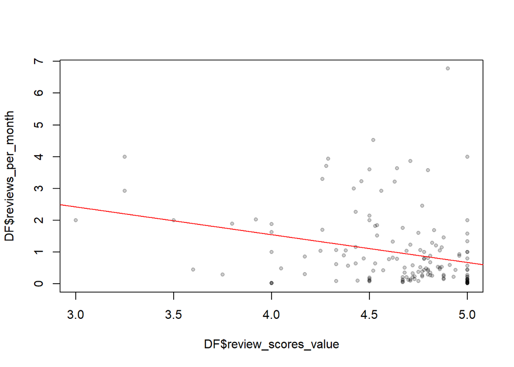

```r
plot(DF$review_scores_value,DF$reviews_per_month, pch=20, col=rgb(0,0,0,0.2)) #pch indica el icono para representar los elementos
abline(lm(DF$reviews_per_month ~ DF$review_scores_value), col = "red") #Se coloca en orden contrario al plot
```

Observamos que los datos siguen una tendencia pero es baja.

## Conclusiones de las relaciones de review_scores_value

La limpieza es la variable que más relación lineal tiene con la puntuación general del hospedaje, es decir, la limpieza influye fuertemente en la valoración de un hospedaje en Francia. Además, también influyen los puntajes de atención al cliente y la localización, pero en menor medida. El resto de variables no influyen.

## Variables que se relacionen con price

También nos interesa saber qué variables se relacionan con el precio, puesto que el estudio va dirigido a los dueños de hospedajes que buscan un precio justo acorde a lo que ofrezcan.

## Relación entre price y bathrooms_text

### Correlación

```r
cor(DF$price,DF$bathrooms_text,use="complete.obs")
```

```
## [1] 0.5294349
```

Existe una relación lineal entre estas 2 variables.

### Gráfica de dispersión

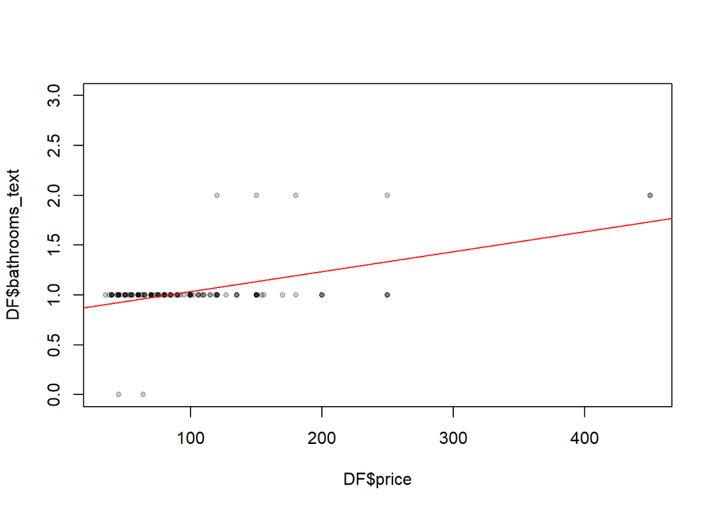

```r
plot(DF$price,DF$bathrooms_text, pch=20, col=rgb(0,0,0,0.2)) #pch indica el icono para representar los elementos
abline(lm(DF$bathrooms_text ~ DF$price), col = "red") #Se coloca en orden contrario al plot
```

## Relación entre price y bedrooms

### Correlación

```r
cor(DF$price,DF$bedrooms,use="complete.obs")
```

```
## [1] 0.6225654
```

### Gráfica de dispersión

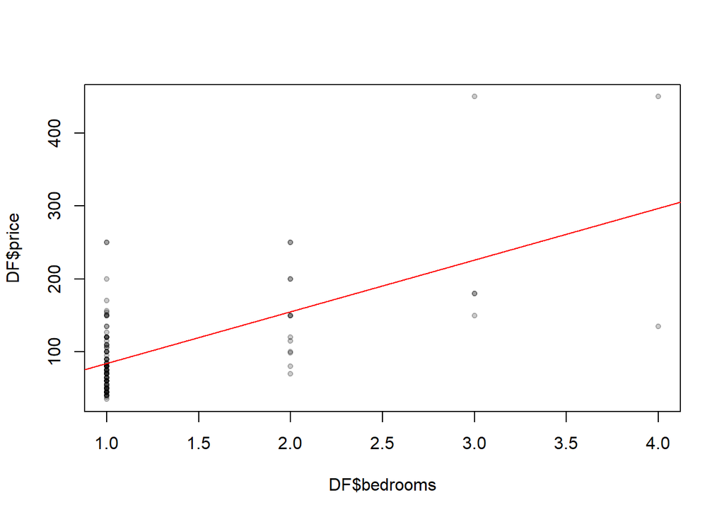

```r
plot(DF$bedrooms,DF$price, pch=20, col=rgb(0,0,0,0.2)) #pch indica el icono para representar los elementos
abline(lm(DF$price ~ DF$bedrooms), col = "red") #Se coloca en orden contrario al plot
```

Observamos que los datos siguen una leve tendencia.

## Relación entre price y beds

### Correlación

```r
cor(DF$price,DF$beds,use="complete.obs")
```

```
## [1] 0.6222856
```

La relación lineal es moderada entre estas 2 variables.

### Gráfica de dispersión

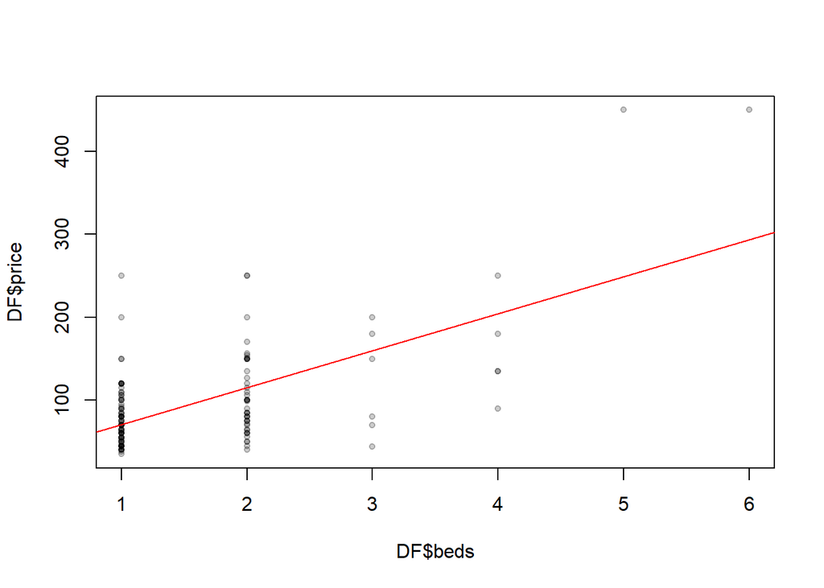

```r
plot(DF$beds,DF$price, pch=20, col=rgb(0,0,0,0.2)) #pch indica el icono para representar los elementos
abline(lm(DF$price ~ DF$beds), col = "red") #Se coloca en orden contrario al plot
```

Se observa que los datos siguen una tendencia, no se encuentran muy dispersos. ## Relación entre price y review_scores_cleanliness

### Correlación

```r
cor(DF$price,DF$review_scores_cleanliness,use="complete.obs")
```

```
## [1] -0.01807653
```

La relación prácticamente es nula entre estas 2 variables.

### Gráfica de dispersión

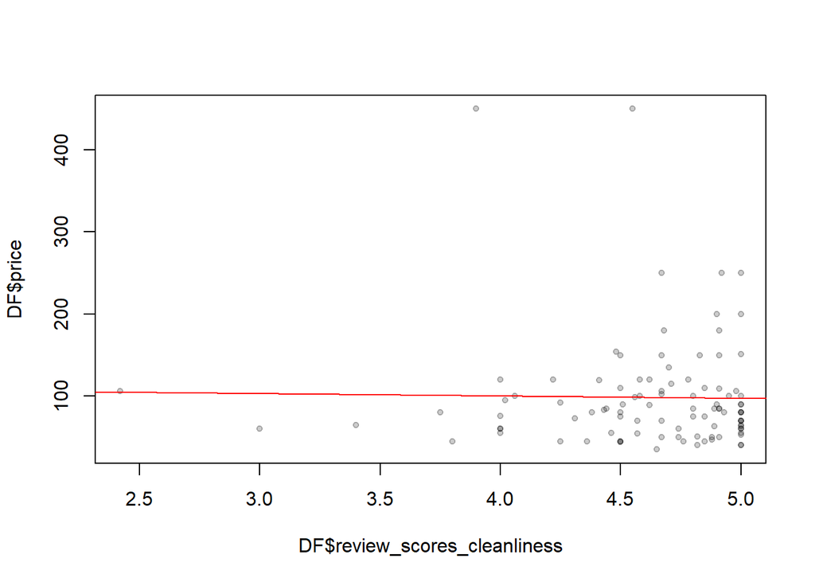

```r
plot(DF$review_scores_cleanliness,DF$price, pch=20, col=rgb(0,0,0,0.2)) #pch indica el icono para representar los elementos
abline(lm(DF$price ~ DF$review_scores_cleanliness), col = "red") #Se coloca en orden contrario al plot
```

Se observa que los datos se encuentran bastante dispersos, por tanto la correlación es casi nula. ## Relación entre price y review_scores_checkin

### Correlación

```r
cor(DF$price,DF$review_scores_checkin,use="complete.obs")
```

```
## [1] -0.09098618
```

La relación prácticamente es nula entre estas 2 variables.

### Gráfica de dispersión

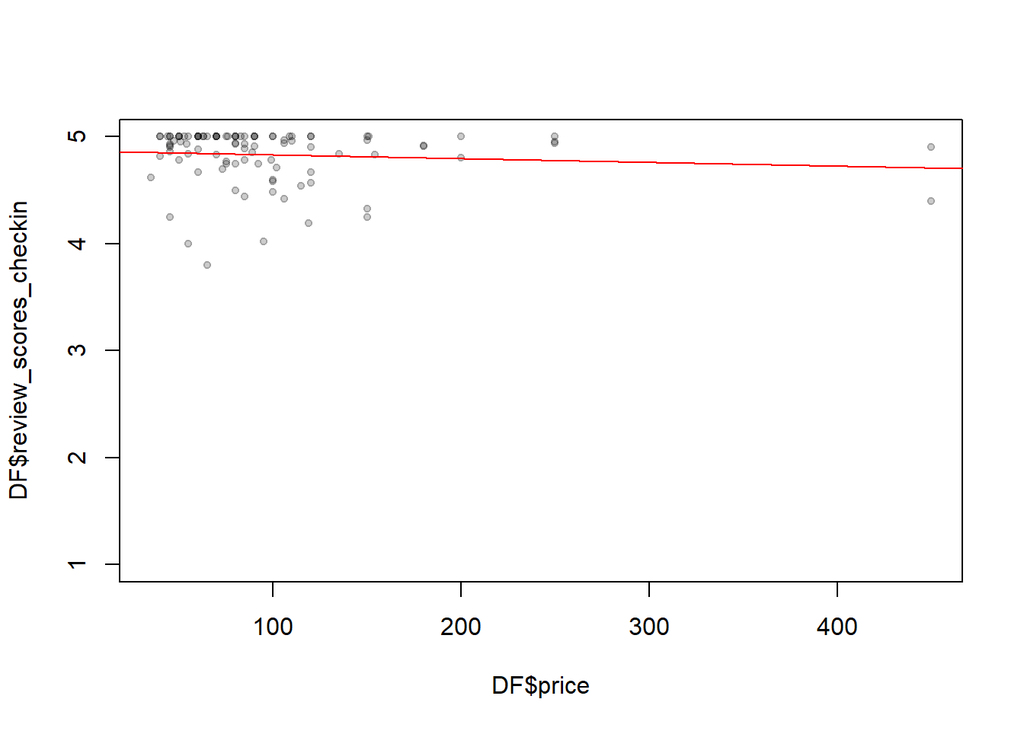

```r
plot(DF$price,DF$review_scores_checkin, pch=20, col=rgb(0,0,0,0.2)) #pch indica el icono para representar los elementos
abline(lm(DF$review_scores_checkin ~ DF$price), col = "red") #Se coloca en orden contrario al plot
```

Se observa que los datos se encuentran bastante disperso, esto explica su correlación nula.

## Relación entre price y review_scores_communication

### Correlación

```r
cor(DF$price,DF$review_scores_communication,use="complete.obs")
```

```
## [1] -0.03198961
```

La relación prácticamente es nula entre estas 2 variables.

### Gráfica de dispersión

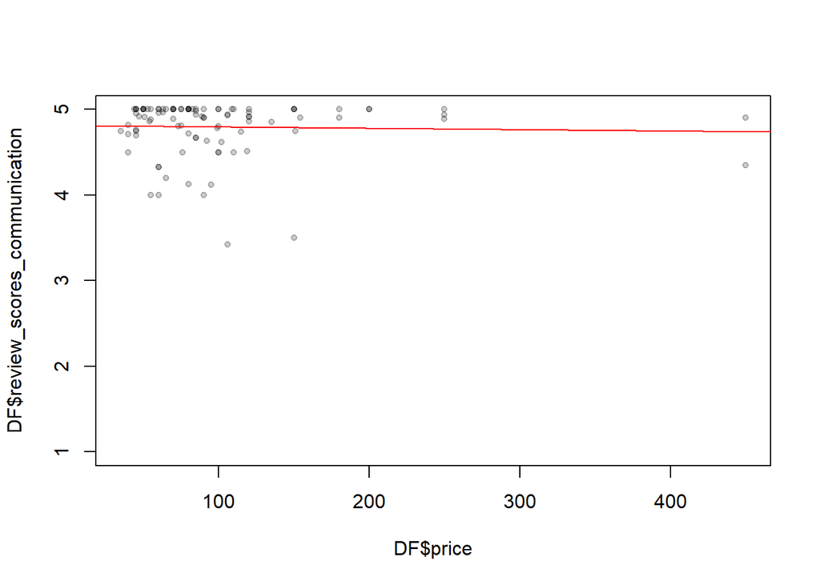

```r
plot(DF$price,DF$review_scores_communication, pch=20, col=rgb(0,0,0,0.2)) #pch indica el icono para representar los elementos
abline(lm(DF$review_scores_communication ~ DF$price), col = "red") #Se coloca en orden contrario al plot
```

Se observa que los datos se encuentran dispersos, no siguen una tendencia.

## Relación entre price y review_scores_location

### Correlación

```r
cor(DF$price,DF$review_scores_location,use="complete.obs")
```

```
## [1] -0.01174783
```

La relación prácticamente es nula entre estas 2 variables.

### Gráfica de dispersión

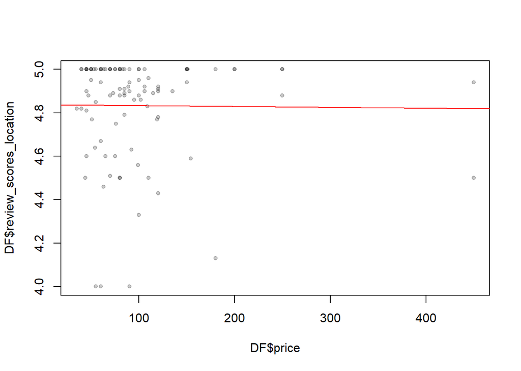

```r
plot(DF$price,DF$review_scores_location, pch=20, col=rgb(0,0,0,0.2))
abline(lm(DF$review_scores_location ~ DF$price), col = "red")
```

Se observa que los datos se encuentran bastante dispersos, por ende la correlación e nula.

## Relación entre price y reviews_per_month

### Correlación

```r
cor(DF$price,DF$reviews_per_month,use="complete.obs")
```

```
## [1] 0.01143143
```

La relación prácticamente es nula entre estas 2 variables.

### Gráfica de dispersión

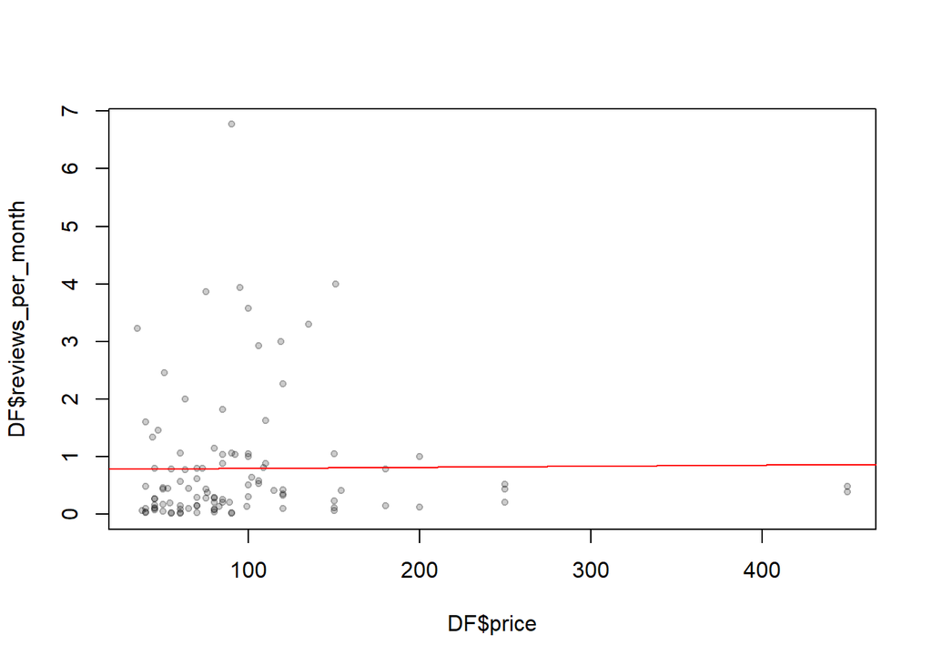

```r
plot(DF$price,DF$reviews_per_month, pch=20, col=rgb(0,0,0,0.2))
abline(lm(DF$reviews_per_month ~ DF$price), col = "red")
```

Se observa que los datos se encuentran dispersos, no siguen una tendencia, por ende una correlación nula.

## Relación entre price y number_of_reviews

### Correlación

```r
cor(DF$price,DF$number_of_reviews,use="complete.obs")
```

```
## [1] 0.02934947
```

La relación prácticamente es nula entre estas 2 variables.

### Gráfica de dispersión

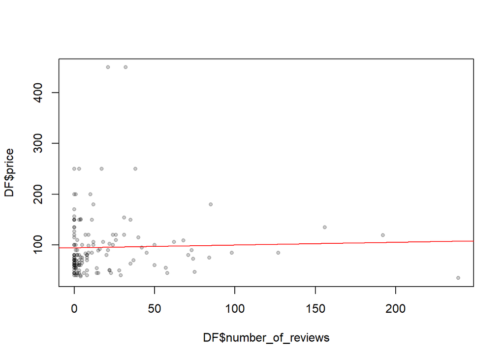

```r
plot(DF$number_of_reviews,DF$price, pch=20, col=rgb(0,0,0,0.2)) #pch indica el icono para representar los elementos
abline(lm(DF$price ~ DF$number_of_reviews), col = "red") #Se coloca en orden contrario al plot
```

Observamos que los datos se encuentran dispersos, no siguen ninguna tendencia, explica la correlación nula.

## Relaciones entre variables categóricas

Esta información puede informar a los dueños de departamente si es que necesitan estar verificados y tener agua caliente para poder competir contra otros hospedajes.

### Mosaico de hot_water y wifi

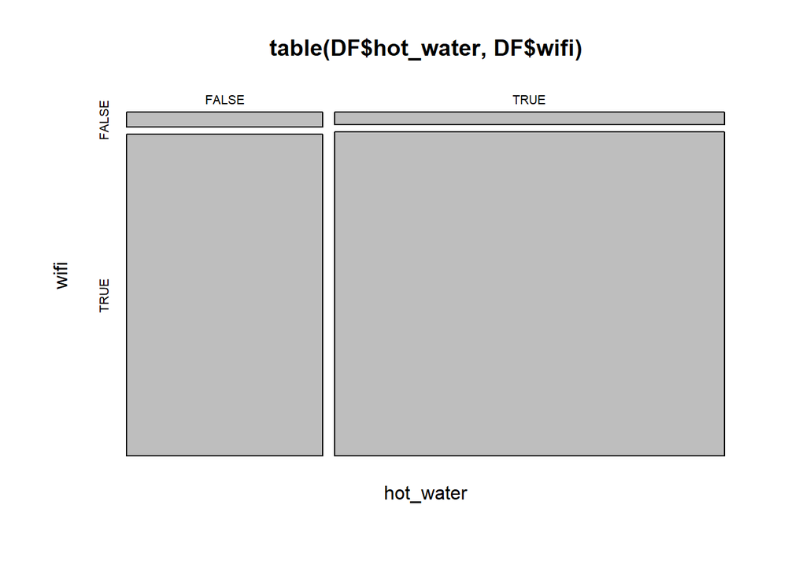

```r
mosaicplot(table(DF$hot_water,DF$wifi), xlab="hot_water", ylab="wifi")
```

Se observa que la mayoría de los hospedajes cuenta con agua caliente y wifi.

## Conclusiones de las relaciones entre 2 variables

1. Las variables que más influyen linealmente en el puntaje de un hospedaje son la limpieza, atención al cliente y la rapidez en el registro. También existe una leve relación lineal con la localización del hospedaje.
2. El precio se ve influido linealmente por la cantidad de baños y dormitorios.
3. Para que un hospedaje pueda competir contra los demás, debe tener mínimamente agua caliente y wifi.

# Relaciones entre 3 variables

Ya hemos determinado cuáles variables se relacionan mejor linealmente. Ahora resumiremos las conclusiones obtenidas en gráficos de 3 variables.

## Diagramas de dispersión

### Relaciones con el Puntaje total

#### Relaciones entre puntaje total, puntaje de limpieza, wifi y agua caliente

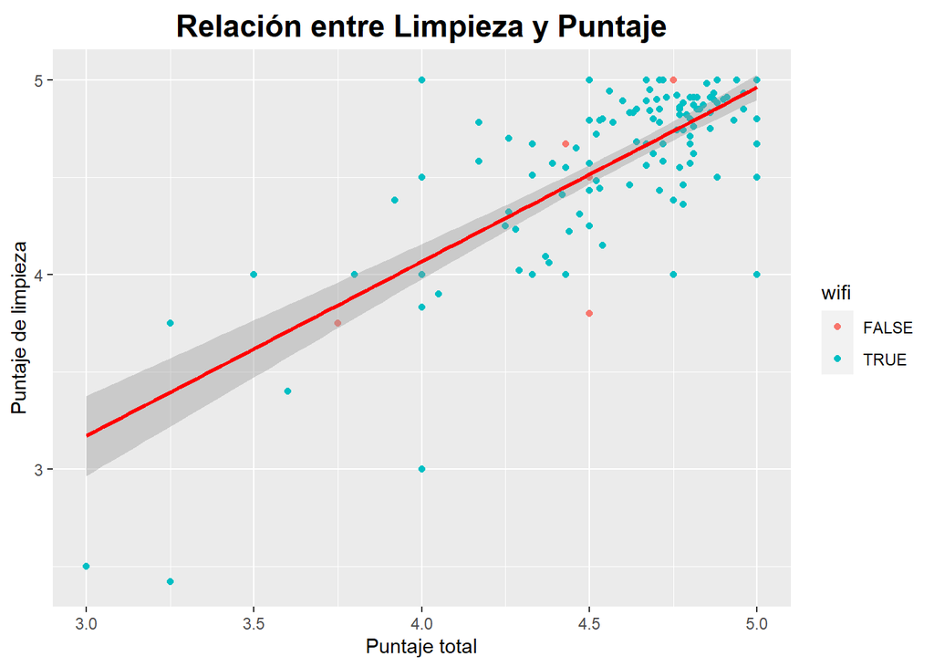

```r
grafica1 <- ggplot(DF,aes(review_scores_value,review_scores_cleanliness,colour=wifi))+
            geom_point() +
            labs(x="Puntaje total",y="Puntaje de limpieza") +
            geom_smooth(method = "lm", colour="Red",formula = y ~ x)+
            ggtitle("Relación entre Limpieza y Puntaje") +
            theme(plot.title=element_text(family="Serif",
                                          size=rel(1.5),
                                          vjust=0.5,hjust=0.5,
                                          face="bold",
                                          lineheigh=1.5))

suppressWarnings(print(grafica1))
```

Se observa claramente que la mayoría de hospedajes tienen Wifi.

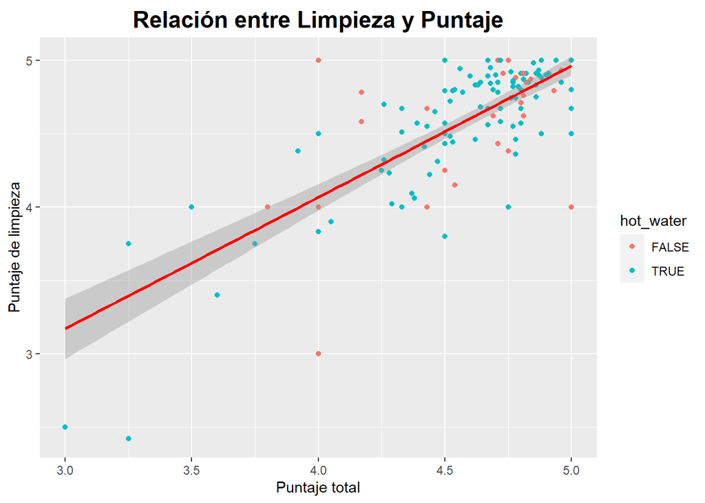

```r
grafica2 <- ggplot(DF,aes(review_scores_value,review_scores_cleanliness,colour=hot_water))+
            geom_point() +
            labs(x="Puntaje total",y="Puntaje de limpieza") +
            geom_smooth(method = "lm", colour="Red",formula = y ~ x)+
            ggtitle("Relación entre Limpieza y Puntaje") +
            theme(plot.title=element_text(family="Serif",
                                          size=rel(1.5),
                                          vjust=0.5,hjust=0.5,
                                          face="bold",
                                          lineheigh=1.5))

suppressWarnings(print(grafica2))
```

Se observa que la mayoría de hospedajes tiene agua caliente, pero hay varios hospedajes que no cuentan con este servicio.

#### Relaciones entre puntaje total, puntaje de check-in, wifi y agua caliente

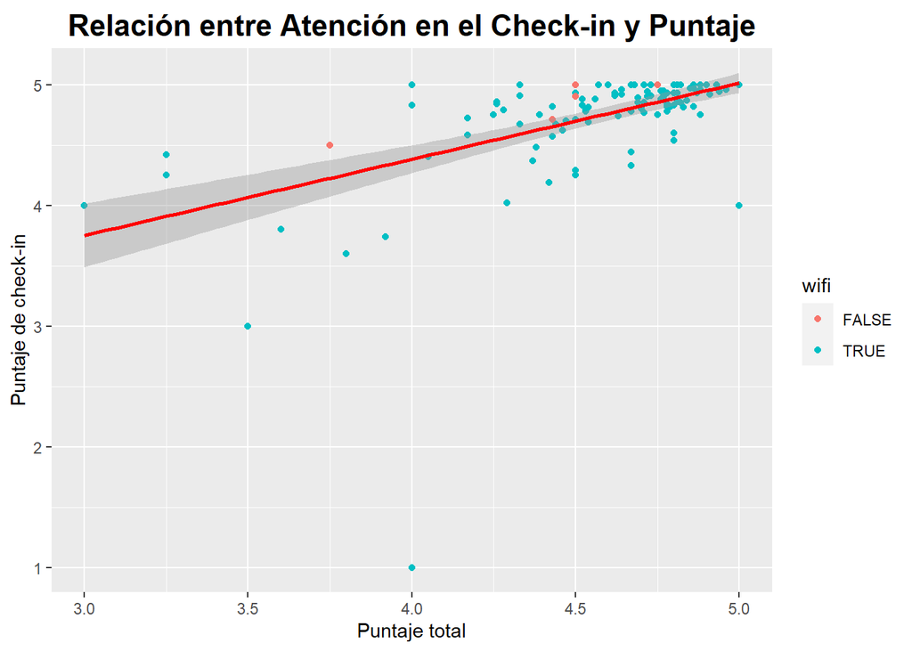

```r
grafica1 <- ggplot(DF,aes(review_scores_value,review_scores_checkin,colour=wifi))+
            geom_point() +
            labs(x="Puntaje total",y="Puntaje de check-in") +
            geom_smooth(method = "lm", colour="Red",formula = y ~ x)+
            ggtitle("Relación entre Atención en el Check-in y Puntaje") +
            theme(plot.title=element_text(family="Serif",
                                          size=rel(1.5),
                                          vjust=0.5,hjust=0.5,
                                          face="bold",
                                          lineheigh=1.5))

suppressWarnings(print(grafica1))
```

Se observa que entre estas tres variables existe una pequeña relación, notamos que los puntos siguen una tendencia leve.

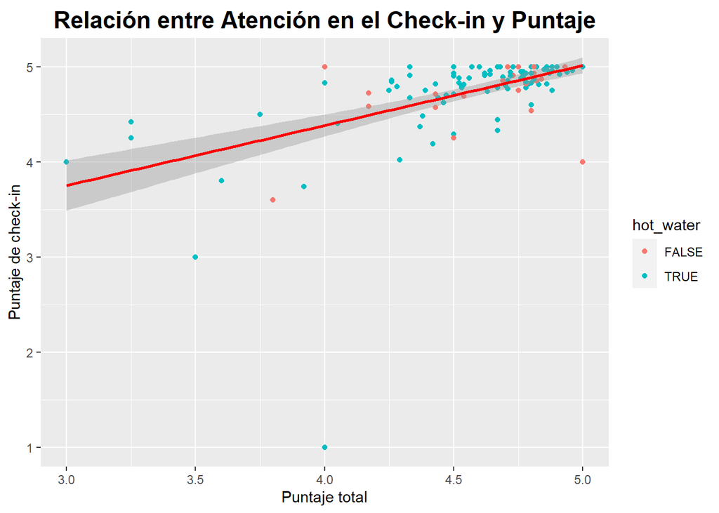

```r
grafica2 <- ggplot(DF,aes(review_scores_value,review_scores_checkin,colour=hot_water))+
            geom_point() +
            labs(x="Puntaje total",y="Puntaje de check-in") +
            geom_smooth(method = "lm", colour="Red",formula = y ~ x)+
            ggtitle("Relación entre Atención en el Check-in y Puntaje") +
            theme(plot.title=element_text(family="Serif",
                                          size=rel(1.5),
                                          vjust=0.5,hjust=0.5,
                                          face="bold",
                                          lineheigh=1.5))

suppressWarnings(print(grafica2))
```

Se observa que la relación entre estas tres variables existe, pero es mínima.

#### Relaciones entre puntaje total, puntaje de atención al cliente, wifi y agua caliente

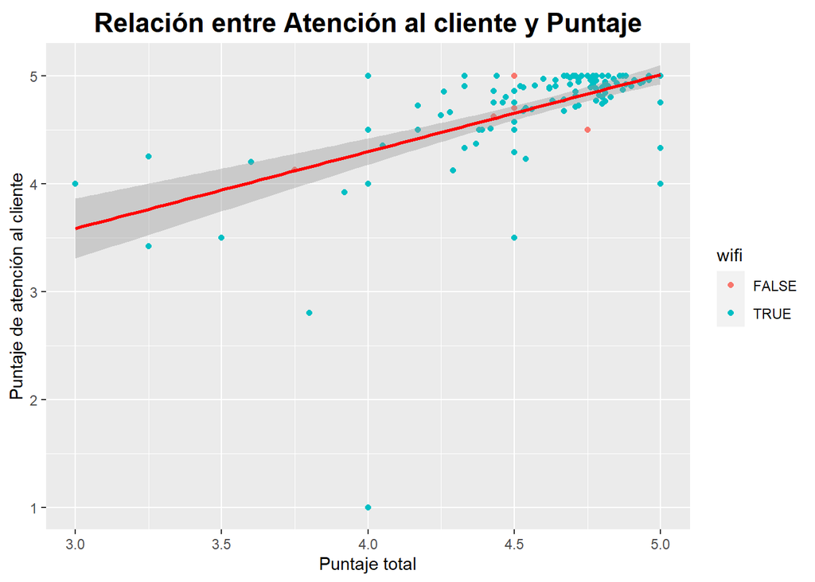

```r
grafica1 <- ggplot(DF,aes(review_scores_value,review_scores_communication,colour=wifi))+
            geom_point() +
            labs(x="Puntaje total",y="Puntaje de atención al cliente") +
            geom_smooth(method = "lm", colour="Red",formula = y ~ x)+
            ggtitle("Relación entre Atención al cliente y Puntaje") +
            theme(plot.title=element_text(family="Serif",
                                          size=rel(1.5),
                                          vjust=0.5,hjust=0.5,
                                          face="bold",
                                          lineheigh=1.5))

suppressWarnings(print(grafica1))
```

Se observa que la relación entre las tres variables existe, ya que los puntos siguen una tendencia.

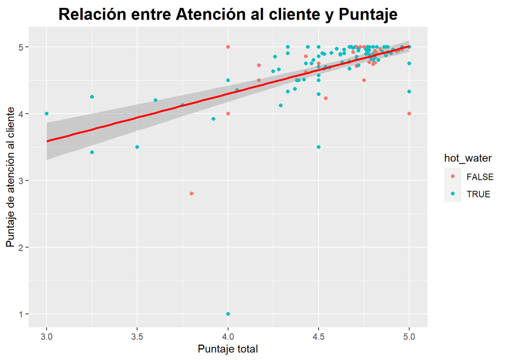

```r
grafica2 <- ggplot(DF,aes(review_scores_value,review_scores_communication,colour=hot_water))+
            geom_point() +
            labs(x="Puntaje total",y="Puntaje de atención al cliente") +
            geom_smooth(method = "lm", colour="Red",formula = y ~ x)+
            ggtitle("Relación entre Atención al cliente y Puntaje") +
            theme(plot.title=element_text(family="Serif",
                                          size=rel(1.5),
                                          vjust=0.5,hjust=0.5,
                                          face="bold",
                                          lineheigh=1.5))

suppressWarnings(print(grafica2))
```

Observamos que la relación entre estas tres variables existe, por tanto los puntos siguen una tendencia.

#### Relaciones entre puntaje total, puntaje de localización, wifi y agua caliente

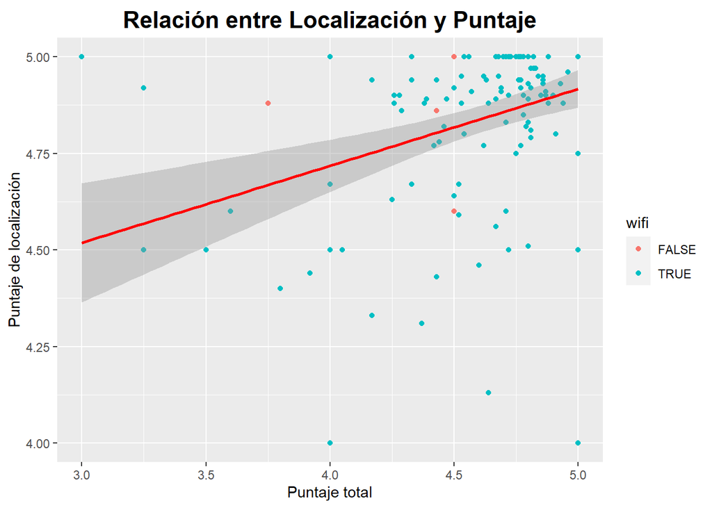

```r
grafica1 <- ggplot(DF,aes(review_scores_value,review_scores_location,colour=wifi))+
            geom_point() +
            labs(x="Puntaje total",y="Puntaje de localización") +
            geom_smooth(method = "lm", colour="Red",formula = y ~ x)+
            ggtitle("Relación entre Localización y Puntaje") +
            theme(plot.title=element_text(family="Serif",
                                          size=rel(1.5),
                                          vjust=0.5,hjust=0.5,
                                          face="bold",
                                          lineheigh=1.5))

suppressWarnings(print(grafica1))
```

Análisis:

- Se observa que en su mayoría los hospedajes cuentan con Wifi.

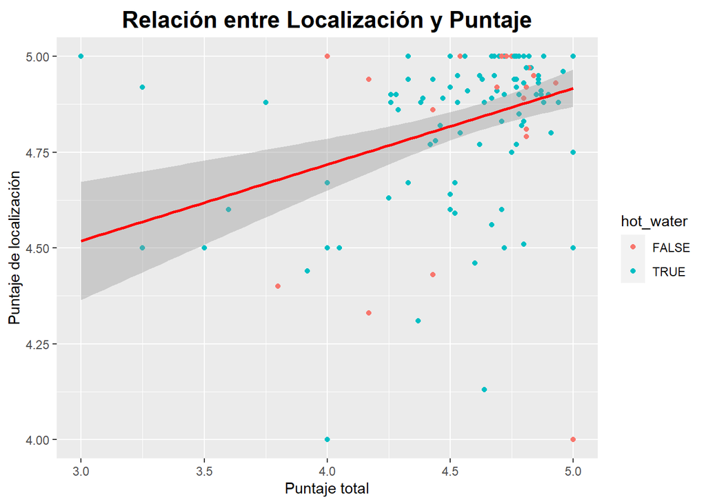

```r
grafica2 <- ggplot(DF,aes(review_scores_value,review_scores_location,colour=hot_water))+
            geom_point() +
            labs(x="Puntaje total",y="Puntaje de localización") +
            geom_smooth(method = "lm", colour="Red",formula = y ~ x)+
            ggtitle("Relación entre Localización y Puntaje") +
            theme(plot.title=element_text(family="Serif",
                                          size=rel(1.5),
                                          vjust=0.5,hjust=0.5,
                                          face="bold",
                                          lineheigh=1.5))

suppressWarnings(print(grafica2))
```

Los hospedajes con agua caliente son más que los que no cuentan con este servicio, pero no son pocos los que aún no cuentan con éste.

### Relaciones con el precio

#### Relaciones con el precio, cantidad de baños, disponibilidad de wifi y agua caliente

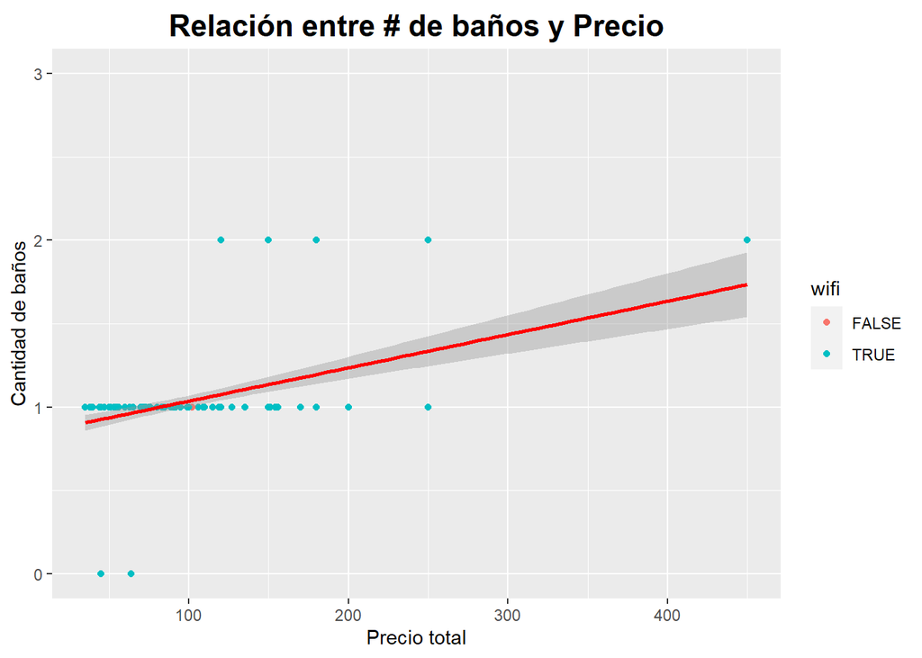

```r
grafica1 <- ggplot(DF,aes(price,bathrooms_text,colour=wifi))+
            geom_point() +
            labs(x="Precio total",y="Cantidad de baños") +
            geom_smooth(method = "lm", colour="Red",formula = y ~ x)+
            ggtitle("Relación entre # de baños y Precio") +
            theme(plot.title=element_text(family="Serif",
                                          size=rel(1.5),
                                          vjust=0.5,hjust=0.5,
                                          face="bold",
                                          lineheigh=1.5))

suppressWarnings(print(grafica1))
```

```r
cor(DF$price,DF$bathrooms_text,use="complete.obs")
```

```
## [1] 0.5294349
```

La cantidad de baños tiene una relación lineal con el precio del hospedaje.

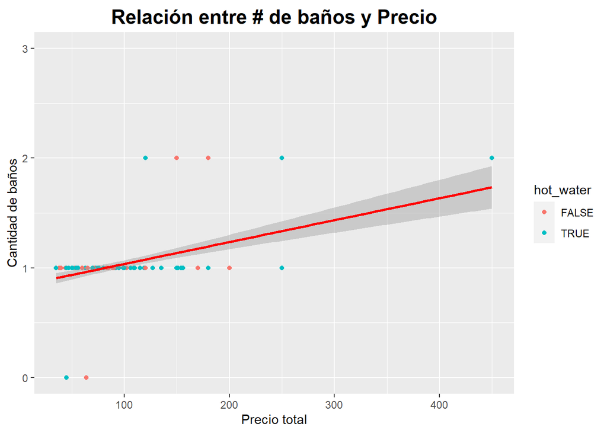

```r
grafica2 <- ggplot(DF,aes(price,bathrooms_text,colour=hot_water))+
            geom_point() +
            labs(x="Precio total",y="Cantidad de baños") +
            geom_smooth(method = "lm", colour="Red",formula = y ~ x)+
            ggtitle("Relación entre # de baños y Precio") +
            theme(plot.title=element_text(family="Serif",
                                          size=rel(1.5),
                                          vjust=0.5,hjust=0.5,
                                          face="bold",
                                          lineheigh=1.5))

suppressWarnings(print(grafica2))
```

#### Relaciones con el precio, cantidad de dormitorios, disponibilidad de wifi y agua caliente

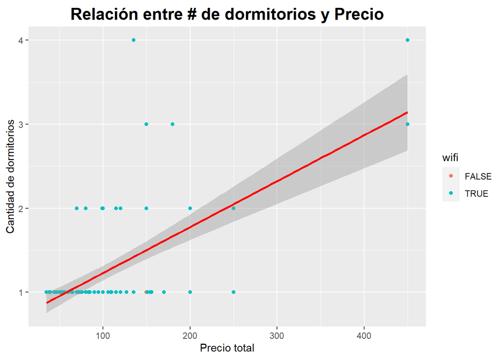

```r
grafica1 <- ggplot(DF,aes(price,bedrooms,colour=wifi))+
            geom_point() +
            labs(x="Precio total",y="Cantidad de dormitorios") +
            geom_smooth(method = "lm", colour="Red",formula = y ~ x)+
            ggtitle("Relación entre # de dormitorios y Precio") +
            theme(plot.title=element_text(family="Serif",
                                          size=rel(1.5),
                                          vjust=0.5,hjust=0.5,
                                          face="bold",
                                          lineheigh=1.5))

suppressWarnings(print(grafica1))
```

La cantidad de dormitorios tiene una relación lineal con el precio del hospedaje.

```r
cor(DF$price,DF$bedrooms,use="complete.obs")
```

```
## [1] 0.6225654
```

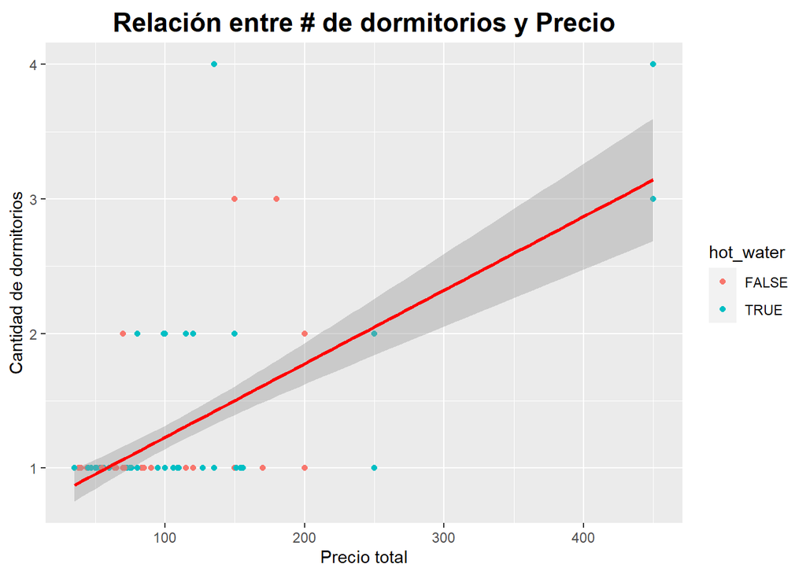

```r
grafica2 <- ggplot(DF,aes(price,bedrooms,colour=hot_water))+
            geom_point() +
            labs(x="Precio total",y="Cantidad de dormitorios") +
            geom_smooth(method = "lm", colour="Red",formula = y ~ x)+
            ggtitle("Relación entre # de dormitorios y Precio") +
            theme(plot.title=element_text(family="Serif",
                                          size=rel(1.5),
                                          vjust=0.5,hjust=0.5,
                                          face="bold",
                                          lineheigh=1.5))

suppressWarnings(print(grafica2))
```

## Boxplots

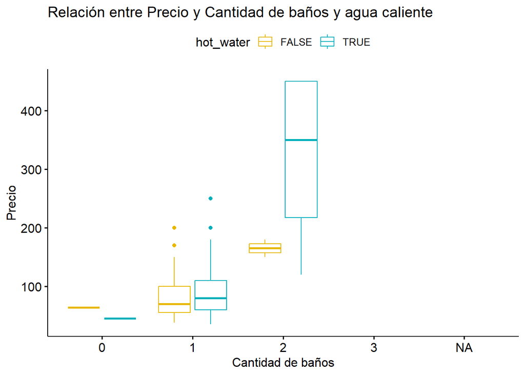

```r
P5 <- ggboxplot(
  title = "Relación entre Precio y Cantidad de baños y agua caliente",
  DF, x="bathrooms_text",y="price", color="hot_water",
  palette=c("#E7B800","#00AFBB"),
  ylab="Precio",xlab="Cantidad de baños"
)


suppressWarnings(print(P5))
```

Análisis:

- Solo existen hospedajes con 0, 1 o 2 baños.
- En el caso de los que no tienen baño, sorprendentemente el precio es mayor cuando no cuentan con agua caliente.
- En cambio, en el caso de los que tienen 1 o 2 baños, el precio es mayor cuando cuentan con agua caliente
- La diferencia de precio en los hospedajes con agua caliente y los que no cuentan con este servicio aumenta a medida que hay más baños.

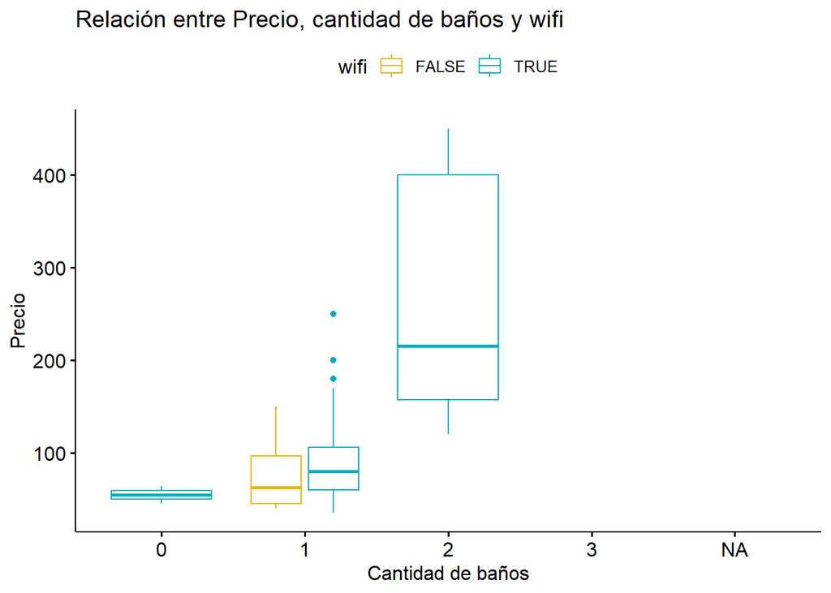

```r
P1 <- ggboxplot(
  title = "Relación entre Precio, cantidad de baños y wifi",
  DF, x="bathrooms_text",y="price", color="wifi",
  palette=c("#E7B800","#00AFBB"),
  ylab="Precio",xlab="Cantidad de baños"
)

suppressWarnings(print(P1))
```

- El único caso en que hay baños, pero no hay wifi se da en los hospedajes con 1 solo baño.
- En todos los hospedajes el precio es mayor cuando este cuenta con Wifi.

# Análisis probabilístico

## Identificación de modelos

### Modelo Normal

#### Review_scores_value

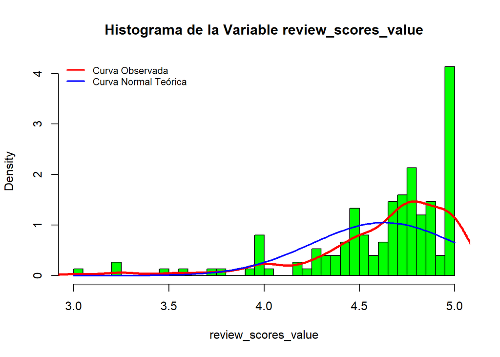

```r
hist(DF$review_scores_value, breaks=40, freq=FALSE, main="Histograma de la Variable review_scores_value", xlab="review_scores_value", col="green")
lines(density(DF$review_scores_value, na.rm=TRUE), col="red", lwd=3)
mu <- mean(DF$review_scores_value, na.rm=TRUE)
sigma <- sd(DF$review_scores_value, na.rm=TRUE)
curve(dnorm(x,mu,sigma),lwd = 2, col="blue", add = TRUE)
legend("topleft", c("Curva Observada", "Curva Normal Teórica"), col= c("red","blue"), lty=1, lwd=2, bty="n", cex=0.8 )
```

#### Latitude

```r
hist(DF$latitude, breaks=10, freq=FALSE, main="Histograma de la Variable Latitude", xlab="Latitud", col="green")
lines(density(DF$latitude, na.rm=TRUE), col="red", lwd=3)
mu <- mean(DF$latitude, na.rm=T)
mu
```

```
## [1] 48.86383
```

```r
sigma <- sd(DF$latitude, na.rm=T)
sigma
```

```
## [1] 0.01885864
```

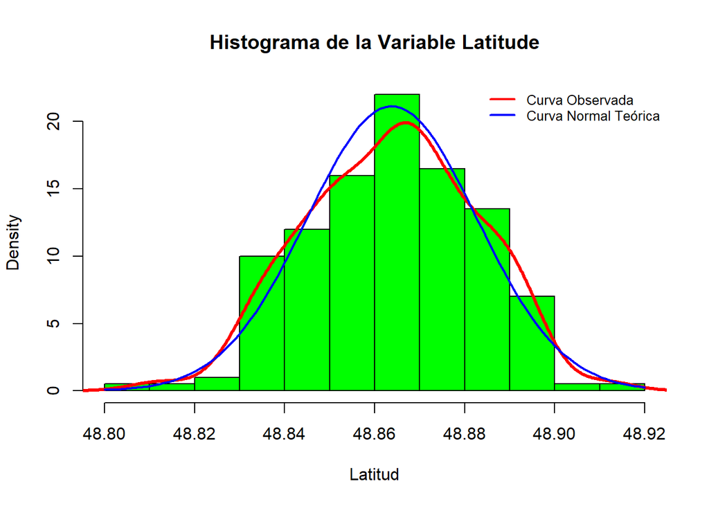

```r
#Con mu y sigma calculamos la distribución Normal más aproximada a nuestra variable
curve(dnorm(x,mu,sigma),lwd = 2, col="blue", add = T)
legend("topright", c("Curva Observada", "Curva Normal Teórica"), col= c("red","blue"), lty=1, lwd=2, bty="n", cex=0.8 ) #topright es la posición de la leyenda
```

Se puede observar que la función de densidad de probabilidad de la variable Latitude tiene una curva similar a la curva de la distribución Normal Teórica.

### Modelo Exponencial

#### Number_of_reviews

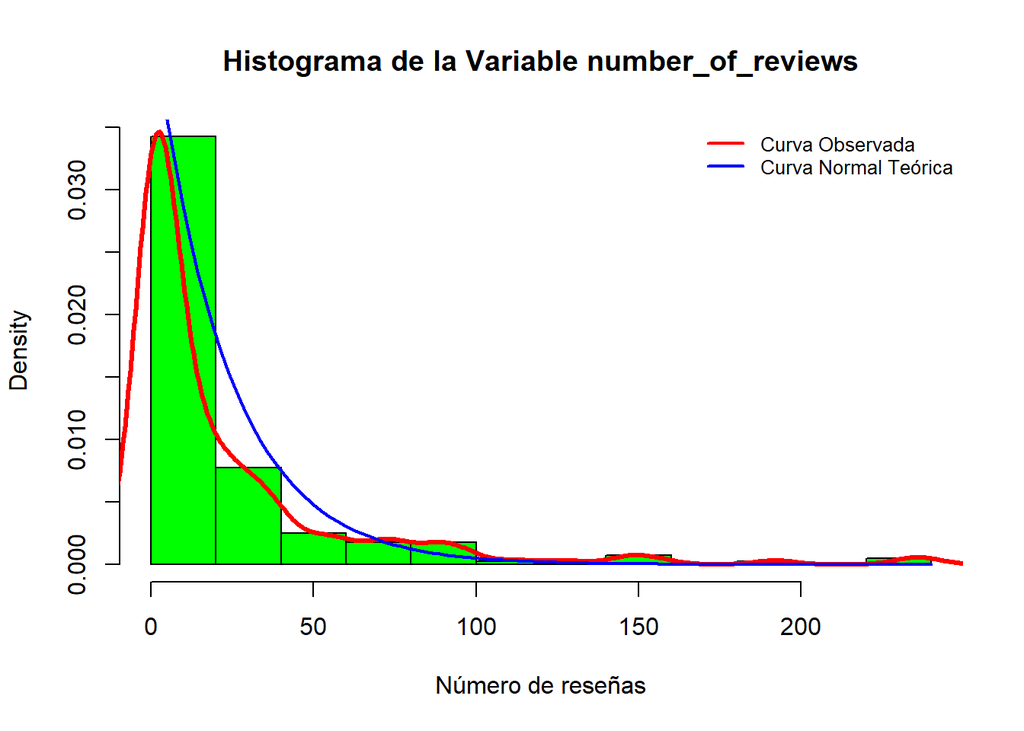

```r
hist(DF$number_of_reviews, breaks=10, freq=FALSE, main="Histograma de la Variable number_of_reviews", xlab="Número de reseñas", col="green")
lines(density(DF$number_of_reviews, na.rm=TRUE), col="red", lwd=3)

esperanza <- mean(DF$number_of_reviews,na.rm=T)
lambda <- 1/esperanza

#Con la Esperanza calculamos la distribución Normal más aproximada a nuestra variable
curve(dexp(x,lambda),lwd = 2, col="blue", add = T)
legend("topright", c("Curva Observada", "Curva Normal Teórica"), col= c("red","blue"), lty=1, lwd=2, bty="n", cex=0.8 ) #topright es la posición de la leyenda
```

## Problemas que se pueden resolver

### Puntaje de un hospedaje

El puntaje que recibe un hospedaje en París está sujeto a una variable aleatoria con distribución Normal tal que X~Norm(mu,sigma). Si los puntajes que pueden recibir son todos los números reales entre 0 y 5, ¿cuál es la probabilidad de que un hospedaje reciba un puntaje menor o igual que 4?

Solución:

A partir de nuestra muestra, sabemos los valores de mu (media) y sigma (desviación estándar).

```r
mu <- mean(DF$review_scores_value,na.rm=T)
#mu
sigma <- sd(DF$review_scores_value,na.rm=T)
#sigma

round(pnorm(4,mu,sigma),2)
```

```
## [1] 0.05
```

Respuesta: La probabilidad es del 5% aprox.

### Latitud de un hospedaje

Una familia francesa está buscando un lugar para ir de paseo en París. La madre propone como idea elegir un hospedaje cuya latitud se elija al azar mediante un aplicativo móvil muy preciso. Si se sabe que la latitud se comporta como una variable aleatoria con distribución Normal Y~Norm(mu,sigma), ¿cuál es la probabilidad de que el hospedaje elegido tenga latitud mayor a 48.85?

```r
mu <- mean(DF$latitude, na.rm=T)
sigma <- sd(DF$latitude, na.rm=T)

round(pnorm(48.85,mu,sigma,lower.tail=F),2)
```

```
## [1] 0.77
```

Respuesta: La probabilidad es del 77% aprox.

### Cantidad de opiniones

Un preocupado dueño de un hospedaje en París desea saber si es que la cantidad de opiniones que recibe es menor de lo que la mayoría de hospedajes reciben. Por lo tanto, decide hallar la probabilidad de que un hospedaje en París haya recibido más opiniones que el suyo. Si la cantidad de opiniones que recibió hasta la fecha es 23, ¿el dueño tiene razones para estar preocupado?

```r
esperanza <- mean(DF$number_of_reviews,na.rm=T)
lambda <- 1/esperanza

pexp(23,lambda,lower.tail = F)
```

```
## [1] 0.3593856
```

Respuesta: No, ya que la probabilidad de que un hospedaje en París tenga más opiniones que él es solo del 36% aprox., lo que quiere decir que la mayoría tiene menos opiniones que él.

## Conclusiones y recomendaciones finales

- Los dueños de hospedajes deben invertir más en limpieza, atención al cliente y la rapidez en el registro del cliente para obtener mejores ganancias.
- Si el dueño piensa en adicionar baños, dormitorios y camas, debe de aumentar el precio en consecuencia para no perder dinero.
- Casi todo hospedaje tiene el servicio de Wifi. En consecuencia, los dueños de hospedajes deben de contratar servicio de Wifi para competir contra los demás.
- La probabilidad de obtener 4 o menos puntos (de 5 en total) de calificación es del 5% aprox., lo que indica que, en general, los hospedajes en París son de buena calidad.

## Correcciones respecto a la PG1

- Diagrama de Gant ahora contiene plazos desde semana 1 hasta la entrega del proyecto.
- Colocamos descriptores numéricos de 1, 2 y 3 variables (con su respectivo análisis) de las variables más relevantes en el estudio.
- Colocamos títulos y etiquetas a los gráficos más importantes.
- Presentamos boxplots y gráficas de barras.
- Realizamos un análisis de todos los descriptores gráficos.
- Explicamos más detalladamente los patrones hallados para las variables más relevantes (relaciones lineales entre variables).

# Bibliografía

Get the Data. (s.f.). http://insideairbnb.com/get-the-data/